# **Facial Emotion Detection**

## **EfficientNet Model**

### **Importing EfficientNet Model**

```python
backend.clear_session()

np.random.seed(25)
random.seed(25)
tf.random.set_seed(25)
```

```python
EfficientNet = ap.EfficientNetV2B2(include_top=False,weights="imagenet", input_shape= (48, 48, 3))

EfficientNet.summary()
```

```
Model: "efficientnetv2-b2"
```

```
┏━━━━━━━━━━━━━━━━━━━━━┳━━━━━━━━━━━━━━━━━━━┳━━━━━━━━━━━━┳━━━━━━━━━━━━━━━━━━━┓
┃ Layer (type)        ┃ Output Shape      ┃    Param # ┃ Connected to      ┃
┡━━━━━━━━━━━━━━━━━━━━━╇━━━━━━━━━━━━━━━━━━━╇━━━━━━━━━━━━╇━━━━━━━━━━━━━━━━━━━┩
│ input_layer         │ (None, 48, 48, 3) │          0 │ -                 │
│ (InputLayer)        │                   │            │                   │
├─────────────────────┼───────────────────┼────────────┼───────────────────┤
│ rescaling           │ (None, 48, 48, 3) │          0 │ input_layer[0][0] │
│ (Rescaling)         │                   │            │                   │
├─────────────────────┼───────────────────┼────────────┼───────────────────┤
│ normalization       │ (None, 48, 48, 3) │          0 │ rescaling[0][0]   │
│ (Normalization)     │                   │            │                   │
├─────────────────────┼───────────────────┼────────────┼───────────────────┤
│ stem_conv (Conv2D)  │ (None, 24, 24,    │        864 │ normalization[0]… │
│                     │ 32)               │            │                   │
├─────────────────────┼───────────────────┼────────────┼───────────────────┤
│ stem_bn             │ (None, 24, 24,    │        128 │ stem_conv[0][0]   │
│ (BatchNormalizatio… │ 32)               │            │                   │
├─────────────────────┼───────────────────┼────────────┼───────────────────┤
│ stem_activation     │ (None, 24, 24,    │          0 │ stem_bn[0][0]     │
│ (Activation)        │ 32)               │            │                   │
├─────────────────────┼───────────────────┼────────────┼───────────────────┤
│ block1a_project_co… │ (None, 24, 24,    │      4,608 │ stem_activation[… │
│ (Conv2D)            │ 16)               │            │                   │
├─────────────────────┼───────────────────┼────────────┼───────────────────┤
│ block1a_project_bn  │ (None, 24, 24,    │         64 │ block1a_project_… │
│ (BatchNormalizatio… │ 16)               │            │                   │
├─────────────────────┼───────────────────┼────────────┼───────────────────┤
│ block1a_project_ac… │ (None, 24, 24,    │          0 │ block1a_project_… │
│ (Activation)        │ 16)               │            │                   │
├─────────────────────┼───────────────────┼────────────┼───────────────────┤
│ block1b_project_co… │ (None, 24, 24,    │      2,304 │ block1a_project_… │
│ (Conv2D)            │ 16)               │            │                   │
├─────────────────────┼───────────────────┼────────────┼───────────────────┤
│ block1b_project_bn  │ (None, 24, 24,    │         64 │ block1b_project_… │
│ (BatchNormalizatio… │ 16)               │            │                   │
├─────────────────────┼───────────────────┼────────────┼───────────────────┤
│ block1b_project_ac… │ (None, 24, 24,    │          0 │ block1b_project_… │
│ (Activation)        │ 16)               │            │                   │
├─────────────────────┼───────────────────┼────────────┼───────────────────┤
│ block1b_drop        │ (None, 24, 24,    │          0 │ block1b_project_… │
```

[output cut: 995 more lines]

```
│ block6j_drop        │ (None, 2, 2, 208) │          0 │ block6j_project_… │
│ (Dropout)           │                   │            │                   │
├─────────────────────┼───────────────────┼────────────┼───────────────────┤
│ block6j_add (Add)   │ (None, 2, 2, 208) │          0 │ block6j_drop[0][… │
│                     │                   │            │ block6i_add[0][0] │
├─────────────────────┼───────────────────┼────────────┼───────────────────┤
│ top_conv (Conv2D)   │ (None, 2, 2,      │    292,864 │ block6j_add[0][0] │
│                     │ 1408)             │            │                   │
├─────────────────────┼───────────────────┼────────────┼───────────────────┤
│ top_bn              │ (None, 2, 2,      │      5,632 │ top_conv[0][0]    │
│ (BatchNormalizatio… │ 1408)             │            │                   │
├─────────────────────┼───────────────────┼────────────┼───────────────────┤
│ top_activation      │ (None, 2, 2,      │          0 │ top_bn[0][0]      │
│ (Activation)        │ 1408)             │            │                   │
└─────────────────────┴───────────────────┴────────────┴───────────────────┘
```

```
 Total params: 8,769,374 (33.45 MB)
```

```
 Trainable params: 8,687,086 (33.14 MB)
```

```
 Non-trainable params: 82,288 (321.44 KB)
```

### **Model Building**

```python
transfer_layer_efficientnet = EfficientNet.get_layer('block6e_expand_activation')
EfficientNet.trainable = False
```

```python
x = Flatten()(transfer_layer_efficientnet.output)

x = Dense(256, activation = 'relu')(x)
x = Dense(128, activation = 'relu')(x)
x = BatchNormalization()(x)
x = Dense(64, activation = 'relu')(x)

x = BatchNormalization()(x)

pred = Dense(4, activation = 'softmax')(x)

en_model = Model(EfficientNet.input, pred)
```

### **Compiling and Training the Model**

```python
opt = SGD(learning_rate = 0.001, momentum = 0.9) #set learning rate to 0.001 because even with a patience of 5 and lr=0.01, the model never improved val loss after the first epoch

en_model.compile(loss = "categorical_crossentropy", optimizer = opt, metrics = ["accuracy"])
```

```python
early_stop = EarlyStopping(monitor='val_loss', mode = 'min', patience = 5, verbose = 1, restore_best_weights = True)
checkpoint = ModelCheckpoint('best_en_model.keras', monitor='val_loss', mode = 'min', verbose = 1, save_best_only = True)
reduce_lr = ReduceLROnPlateau(monitor = 'val_loss', factor = 0.2, patience = 3, verbose = 1, min_delta = 0.0001)

history_en_model = en_model.fit(train_set, validation_data = val_set, epochs = 20, verbose = 1, callbacks = [early_stop, checkpoint, reduce_lr])
```

```
473/473 ━━━━━━━━━━━━━━━━━━━━ 0s 35ms/step - accuracy: 0.2643 - loss: 1.4794
Epoch 1: val_loss improved from inf to 1.81241, saving model to best_en_model.keras
473/473 ━━━━━━━━━━━━━━━━━━━━ 33s 51ms/step - accuracy: 0.2643 - loss: 1.4792 - val_accuracy: 0.1601 - val_loss: 1.8124 - learning_rate: 0.0010
472/473 ━━━━━━━━━━━━━━━━━━━━ 0s 35ms/step - accuracy: 0.2649 - loss: 1.3939
Epoch 2: val_loss improved from 1.81241 to 1.40236, saving model to best_en_model.keras
473/473 ━━━━━━━━━━━━━━━━━━━━ 22s 47ms/step - accuracy: 0.2649 - loss: 1.3939 - val_accuracy: 0.3667 - val_loss: 1.4024 - learning_rate: 0.0010
472/473 ━━━━━━━━━━━━━━━━━━━━ 0s 35ms/step - accuracy: 0.2608 - loss: 1.3934
Epoch 3: val_loss did not improve from 1.40236
473/473 ━━━━━━━━━━━━━━━━━━━━ 22s 46ms/step - accuracy: 0.2608 - loss: 1.3934 - val_accuracy: 0.2289 - val_loss: 1.4609 - learning_rate: 0.0010
473/473 ━━━━━━━━━━━━━━━━━━━━ 0s 34ms/step - accuracy: 0.2723 - loss: 1.3865
Epoch 4: val_loss did not improve from 1.40236
473/473 ━━━━━━━━━━━━━━━━━━━━ 21s 45ms/step - accuracy: 0.2723 - loss: 1.3865 - val_accuracy: 0.2289 - val_loss: 1.4855 - learning_rate: 0.0010
473/473 ━━━━━━━━━━━━━━━━━━━━ 0s 33ms/step - accuracy: 0.2598 - loss: 1.3882
Epoch 5: val_loss did not improve from 1.40236

Epoch 5: ReduceLROnPlateau reducing learning rate to 0.00020000000949949026.
473/473 ━━━━━━━━━━━━━━━━━━━━ 21s 44ms/step - accuracy: 0.2598 - loss: 1.3882 - val_accuracy: 0.2441 - val_loss: 1.4089 - learning_rate: 0.0010
473/473 ━━━━━━━━━━━━━━━━━━━━ 0s 32ms/step - accuracy: 0.2702 - loss: 1.3861
Epoch 6: val_loss improved from 1.40236 to 1.35635, saving model to best_en_model.keras
473/473 ━━━━━━━━━━━━━━━━━━━━ 21s 43ms/step - accuracy: 0.2702 - loss: 1.3861 - val_accuracy: 0.3631 - val_loss: 1.3564 - learning_rate: 2.0000e-04
473/473 ━━━━━━━━━━━━━━━━━━━━ 0s 32ms/step - accuracy: 0.2711 - loss: 1.3820
Epoch 7: val_loss did not improve from 1.35635
473/473 ━━━━━━━━━━━━━━━━━━━━ 20s 43ms/step - accuracy: 0.2711 - loss: 1.3820 - val_accuracy: 0.2282 - val_loss: 1.3733 - learning_rate: 2.0000e-04
473/473 ━━━━━━━━━━━━━━━━━━━━ 0s 34ms/step - accuracy: 0.2674 - loss: 1.3836
Epoch 8: val_loss did not improve from 1.35635
473/473 ━━━━━━━━━━━━━━━━━━━━ 21s 44ms/step - accuracy: 0.2674 - loss: 1.3836 - val_accuracy: 0.2293 - val_loss: 1.3697 - learning_rate: 2.0000e-04
473/473 ━━━━━━━━━━━━━━━━━━━━ 0s 34ms/step - accuracy: 0.2774 - loss: 1.3807
Epoch 9: val_loss did not improve from 1.35635

Epoch 9: ReduceLROnPlateau reducing learning rate to 4.0000001899898055e-05.
473/473 ━━━━━━━━━━━━━━━━━━━━ 21s 44ms/step - accuracy: 0.2774 - loss: 1.3807 - val_accuracy: 0.2723 - val_loss: 1.3628 - learning_rate: 2.0000e-04
472/473 ━━━━━━━━━━━━━━━━━━━━ 0s 34ms/step - accuracy: 0.2692 - loss: 1.3830
Epoch 10: val_loss did not improve from 1.35635
473/473 ━━━━━━━━━━━━━━━━━━━━ 21s 44ms/step - accuracy: 0.2692 - loss: 1.3830 - val_accuracy: 0.3106 - val_loss: 1.3633 - learning_rate: 4.0000e-05
473/473 ━━━━━━━━━━━━━━━━━━━━ 0s 35ms/step - accuracy: 0.2751 - loss: 1.3805
Epoch 11: val_loss did not improve from 1.35635
473/473 ━━━━━━━━━━━━━━━━━━━━ 22s 46ms/step - accuracy: 0.2751 - loss: 1.3805 - val_accuracy: 0.3679 - val_loss: 1.3575 - learning_rate: 4.0000e-05
Epoch 11: early stopping
Restoring model weights from the end of the best epoch: 6.
```

### **Model Evaluation**

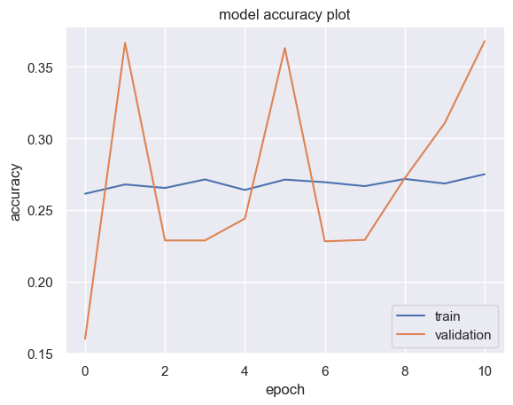

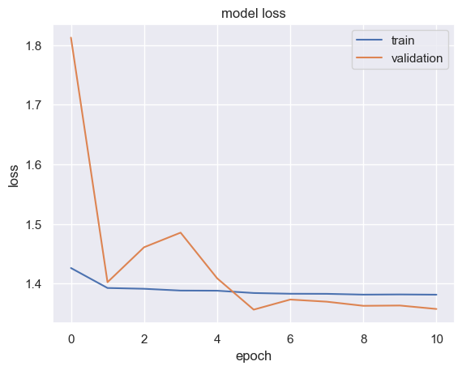

```python
plt.plot(history_en_model.history['accuracy'])
plt.plot(history_en_model.history['val_accuracy'])

plt.title('model accuracy plot')
plt.ylabel('accuracy')
plt.xlabel('epoch')
plt.legend(['train', 'validation'])

plt.show()

plt.plot(history_en_model.history['loss'])
plt.plot(history_en_model.history['val_loss'])

plt.title('model loss')
plt.ylabel('loss')
plt.xlabel('epoch')
plt.legend(['train', 'validation'])

plt.show()
```

```python
accuracy = en_model.evaluate(test_images, test_labels, verbose = 2)
```

```
4/4 - 0s - 29ms/step - accuracy: 0.2578 - loss: 1.3973
```

```python
#saving model name and accuracy
scoreboard_name.append('en_model')
scoreboard_acc.append(accuracy)

scoreboard.append(['en_base', accuracy])

scoreboard.append(['EN', accuracy[1]])
```

**Observations and Insights:**

**Final Transfer Learning Architectures Takeaways**

- The best performing model of the three transfer learning architectures was the VGG16 model, with an accuracy of 44% on the test set.
- They performed very poorly compared to the models we built from scratch.
- The differences in our datasets (train, val, and test) and those on which these models were trained/tested on may have cause the performance issues we are seeing. For example, the dimensions of our input images or domain mismatch.
- Let's move away from transfer learning and back to grayscale.

# **Building a Complex Neural Network Architecture**

### **Creating our Data Loaders**'.

```python
batch_size  = 32

datagen_train = ImageDataGenerator(horizontal_flip = True,
                                    brightness_range=(0.,2.),
                                    rescale=1./255,
                                    shear_range=0.2,)

train_set = datagen_train.flow_from_directory(DATADIR,
                                              target_size = (IMG_SIZE, IMG_SIZE),
                                              color_mode = 'grayscale' ,
                                              batch_size = batch_size,
                                              class_mode = 'categorical',
                                              classes = ['happy', 'neutral', 'sad', 'surprise'],
                                              shuffle = True)


datagen_val = ImageDataGenerator(horizontal_flip = True,
                                    brightness_range=(0.,2.),
                                    rescale=1./255,
                                    shear_range=0.2,)

val_set = datagen_val.flow_from_directory(DATADIR_VAL,
                                              target_size = (IMG_SIZE, IMG_SIZE),
                                              color_mode = 'grayscale' ,
                                              batch_size = batch_size,
                                              class_mode = 'categorical',
                                              classes = ['happy', 'neutral', 'sad', 'surprise'],
                                              shuffle = True)


datagen_test = ImageDataGenerator(horizontal_flip = True,
                                    brightness_range=(0.,2.),
                                    rescale=1./255,
                                    shear_range=0.2,)

test_set = datagen_test.flow_from_directory(DATADIR_TEST,
                                              target_size = (IMG_SIZE, IMG_SIZE),
                                              color_mode = 'grayscale' ,
                                              batch_size = batch_size_testing,
                                              class_mode = 'categorical',
                                              classes = ['happy', 'neutral', 'sad', 'surprise'],
                                              shuffle = True)
```

## **Fourth CNN Model (grayscale)**

### **Model Building and Compiling**

```python
backend.clear_session()

np.random.seed(25)
random.seed(25)
tf.random.set_seed(25)
```

```python
def cnn_model_complex():

    model = Sequential()
    model.add(Input(shape = (IMG_SIZE, IMG_SIZE, 1)))

    # conv1 block
    model.add(Conv2D(filters = 64, kernel_size = (2,2), activation = 'relu', padding='same'))
    model.add(BatchNormalization())
    model.add(LeakyReLU(0.1))
    model.add(MaxPooling2D(pool_size = (2,2)))
    model.add(Dropout(0.2))

    # conv2 block
    model.add(Conv2D(filters = 128, kernel_size = (2,2), activation = 'relu', padding='same'))
    model.add(BatchNormalization())
    model.add(LeakyReLU(0.1))
    model.add(MaxPooling2D(pool_size = (2,2)))
    model.add(Dropout(0.2))

    # conv3 block
    model.add(Conv2D(filters = 512, kernel_size = (2,2), activation = 'relu', padding = 'same'))
    model.add(BatchNormalization())
    model.add(LeakyReLU(0.1))
    model.add(MaxPooling2D(pool_size = (2,2)))
    model.add(Dropout(0.2))

    # conv4 block
    model.add(Conv2D(filters = 512, kernel_size = (2,2), activation = 'relu', padding = 'same'))
    model.add(BatchNormalization())
    model.add(LeakyReLU(0.1))
    model.add(MaxPooling2D(pool_size = (2,2)))
    model.add(Dropout(0.2))

    # conv5 block
    model.add(Conv2D(filters = 512, kernel_size = (2,2), activation = 'relu', padding = 'same'))
    model.add(BatchNormalization())
    model.add(LeakyReLU(0.1))
    model.add(MaxPooling2D(pool_size = (2,2)))
    model.add(Dropout(0.2))

    #flatten
    model.add(Flatten())

    #Dense layers
    model.add(Dense(256))
    model.add(BatchNormalization())
    model.add(Activation('relu'))

    model.add(Dense(512))
    model.add(BatchNormalization())
    model.add(Activation('relu'))
    model.add(Dropout(0.2))

    model.add(Dense(4, activation = 'softmax'))

    opt = SGD(learning_rate = 0.01, momentum = 0.9)

    model.compile(loss = "categorical_crossentropy", optimizer = opt, metrics = ["accuracy"])

    return model
```

```python
cnn4 = cnn_model_complex()
cnn4.summary()
```

```
Model: "sequential"
```

```
┏━━━━━━━━━━━━━━━━━━━━━━━━━━━━━━━━━┳━━━━━━━━━━━━━━━━━━━━━━━━┳━━━━━━━━━━━━━━━┓
┃ Layer (type)                    ┃ Output Shape           ┃       Param # ┃
┡━━━━━━━━━━━━━━━━━━━━━━━━━━━━━━━━━╇━━━━━━━━━━━━━━━━━━━━━━━━╇━━━━━━━━━━━━━━━┩
│ conv2d (Conv2D)                 │ (None, 48, 48, 64)     │           320 │
├─────────────────────────────────┼────────────────────────┼───────────────┤
│ batch_normalization             │ (None, 48, 48, 64)     │           256 │
│ (BatchNormalization)            │                        │               │
├─────────────────────────────────┼────────────────────────┼───────────────┤
│ leaky_re_lu (LeakyReLU)         │ (None, 48, 48, 64)     │             0 │
├─────────────────────────────────┼────────────────────────┼───────────────┤
│ max_pooling2d (MaxPooling2D)    │ (None, 24, 24, 64)     │             0 │
├─────────────────────────────────┼────────────────────────┼───────────────┤
│ dropout (Dropout)               │ (None, 24, 24, 64)     │             0 │
├─────────────────────────────────┼────────────────────────┼───────────────┤
│ conv2d_1 (Conv2D)               │ (None, 24, 24, 128)    │        32,896 │
├─────────────────────────────────┼────────────────────────┼───────────────┤
│ batch_normalization_1           │ (None, 24, 24, 128)    │           512 │
│ (BatchNormalization)            │                        │               │
├─────────────────────────────────┼────────────────────────┼───────────────┤
│ leaky_re_lu_1 (LeakyReLU)       │ (None, 24, 24, 128)    │             0 │
├─────────────────────────────────┼────────────────────────┼───────────────┤
│ max_pooling2d_1 (MaxPooling2D)  │ (None, 12, 12, 128)    │             0 │
├─────────────────────────────────┼────────────────────────┼───────────────┤
│ dropout_1 (Dropout)             │ (None, 12, 12, 128)    │             0 │
├─────────────────────────────────┼────────────────────────┼───────────────┤
│ conv2d_2 (Conv2D)               │ (None, 12, 12, 512)    │       262,656 │
├─────────────────────────────────┼────────────────────────┼───────────────┤
│ batch_normalization_2           │ (None, 12, 12, 512)    │         2,048 │
│ (BatchNormalization)            │                        │               │
├─────────────────────────────────┼────────────────────────┼───────────────┤
│ leaky_re_lu_2 (LeakyReLU)       │ (None, 12, 12, 512)    │             0 │
├─────────────────────────────────┼────────────────────────┼───────────────┤
│ max_pooling2d_2 (MaxPooling2D)  │ (None, 6, 6, 512)      │             0 │
├─────────────────────────────────┼────────────────────────┼───────────────┤
│ dropout_2 (Dropout)             │ (None, 6, 6, 512)      │             0 │
├─────────────────────────────────┼────────────────────────┼───────────────┤
│ conv2d_3 (Conv2D)               │ (None, 6, 6, 512)      │     1,049,088 │
├─────────────────────────────────┼────────────────────────┼───────────────┤
│ batch_normalization_3           │ (None, 6, 6, 512)      │         2,048 │
│ (BatchNormalization)            │                        │               │
```

[output cut: 23 more lines]

```
│ (BatchNormalization)            │                        │               │
├─────────────────────────────────┼────────────────────────┼───────────────┤
│ activation (Activation)         │ (None, 256)            │             0 │
├─────────────────────────────────┼────────────────────────┼───────────────┤
│ dense_1 (Dense)                 │ (None, 512)            │       131,584 │
├─────────────────────────────────┼────────────────────────┼───────────────┤
│ batch_normalization_6           │ (None, 512)            │         2,048 │
│ (BatchNormalization)            │                        │               │
├─────────────────────────────────┼────────────────────────┼───────────────┤
│ activation_1 (Activation)       │ (None, 512)            │             0 │
├─────────────────────────────────┼────────────────────────┼───────────────┤
│ dropout_5 (Dropout)             │ (None, 512)            │             0 │
├─────────────────────────────────┼────────────────────────┼───────────────┤
│ dense_2 (Dense)                 │ (None, 4)              │         2,052 │
└─────────────────────────────────┴────────────────────────┴───────────────┘
```

```
 Total params: 2,668,996 (10.18 MB)
```

```
 Trainable params: 2,664,004 (10.16 MB)
```

```
 Non-trainable params: 4,992 (19.50 KB)
```

### **Training the Model**

```python
early_stop = EarlyStopping(monitor='val_loss', mode = 'min', patience = 5, verbose = 1, restore_best_weights = True)
checkpoint = ModelCheckpoint('best_model_cnn4.keras', monitor='val_loss', mode = 'min', verbose = 1, save_best_only = True)
reduce_lr = ReduceLROnPlateau(monitor = 'val_loss', factor = 0.2, patience = 3, verbose = 1, min_delta = 0.0001)

history_cnn4 = cnn4.fit(train_set, validation_data = val_set, epochs = 200, verbose = 1, callbacks = [early_stop, checkpoint, reduce_lr])
```

```
  1/473 ━━━━━━━━━━━━━━━━━━━━ 16:55 2s/step - accuracy: 0.3750 - loss: 1.5162
```

```
472/473 ━━━━━━━━━━━━━━━━━━━━ 0s 49ms/step - accuracy: 0.2675 - loss: 1.6341
Epoch 1: val_loss improved from inf to 1.46547, saving model to best_model_cnn4.keras
473/473 ━━━━━━━━━━━━━━━━━━━━ 29s 56ms/step - accuracy: 0.2675 - loss: 1.6338 - val_accuracy: 0.2570 - val_loss: 1.4655 - learning_rate: 0.0100
472/473 ━━━━━━━━━━━━━━━━━━━━ 0s 48ms/step - accuracy: 0.2863 - loss: 1.4886
Epoch 2: val_loss did not improve from 1.46547
473/473 ━━━━━━━━━━━━━━━━━━━━ 26s 54ms/step - accuracy: 0.2864 - loss: 1.4885 - val_accuracy: 0.3671 - val_loss: 1.5563 - learning_rate: 0.0100
472/473 ━━━━━━━━━━━━━━━━━━━━ 0s 48ms/step - accuracy: 0.3402 - loss: 1.3719
Epoch 3: val_loss improved from 1.46547 to 1.32087, saving model to best_model_cnn4.keras
473/473 ━━━━━━━━━━━━━━━━━━━━ 26s 54ms/step - accuracy: 0.3402 - loss: 1.3719 - val_accuracy: 0.3064 - val_loss: 1.3209 - learning_rate: 0.0100
473/473 ━━━━━━━━━━━━━━━━━━━━ 0s 50ms/step - accuracy: 0.3876 - loss: 1.2929
Epoch 4: val_loss improved from 1.32087 to 1.24132, saving model to best_model_cnn4.keras
473/473 ━━━━━━━━━━━━━━━━━━━━ 27s 57ms/step - accuracy: 0.3877 - loss: 1.2929 - val_accuracy: 0.4286 - val_loss: 1.2413 - learning_rate: 0.0100
473/473 ━━━━━━━━━━━━━━━━━━━━ 0s 50ms/step - accuracy: 0.4176 - loss: 1.2365
Epoch 5: val_loss did not improve from 1.24132
473/473 ━━━━━━━━━━━━━━━━━━━━ 26s 56ms/step - accuracy: 0.4176 - loss: 1.2364 - val_accuracy: 0.4185 - val_loss: 1.2738 - learning_rate: 0.0100
473/473 ━━━━━━━━━━━━━━━━━━━━ 0s 49ms/step - accuracy: 0.4688 - loss: 1.1780
Epoch 6: val_loss improved from 1.24132 to 1.17360, saving model to best_model_cnn4.keras
473/473 ━━━━━━━━━━━━━━━━━━━━ 26s 56ms/step - accuracy: 0.4688 - loss: 1.1780 - val_accuracy: 0.4712 - val_loss: 1.1736 - learning_rate: 0.0100
473/473 ━━━━━━━━━━━━━━━━━━━━ 0s 49ms/step - accuracy: 0.4951 - loss: 1.1324
Epoch 7: val_loss improved from 1.17360 to 1.06293, saving model to best_model_cnn4.keras
473/473 ━━━━━━━━━━━━━━━━━━━━ 26s 55ms/step - accuracy: 0.4951 - loss: 1.1324 - val_accuracy: 0.5230 - val_loss: 1.0629 - learning_rate: 0.0100
473/473 ━━━━━━━━━━━━━━━━━━━━ 0s 48ms/step - accuracy: 0.5133 - loss: 1.0855
Epoch 8: val_loss improved from 1.06293 to 1.02695, saving model to best_model_cnn4.keras
473/473 ━━━━━━━━━━━━━━━━━━━━ 26s 55ms/step - accuracy: 0.5133 - loss: 1.0855 - val_accuracy: 0.5550 - val_loss: 1.0269 - learning_rate: 0.0100
472/473 ━━━━━━━━━━━━━━━━━━━━ 0s 49ms/step - accuracy: 0.5295 - loss: 1.0645
Epoch 9: val_loss improved from 1.02695 to 1.00881, saving model to best_model_cnn4.keras
473/473 ━━━━━━━━━━━━━━━━━━━━ 26s 55ms/step - accuracy: 0.5295 - loss: 1.0645 - val_accuracy: 0.5678 - val_loss: 1.0088 - learning_rate: 0.0100
472/473 ━━━━━━━━━━━━━━━━━━━━ 0s 49ms/step - accuracy: 0.5510 - loss: 1.0340
Epoch 10: val_loss did not improve from 1.00881
473/473 ━━━━━━━━━━━━━━━━━━━━ 26s 55ms/step - accuracy: 0.5510 - loss: 1.0340 - val_accuracy: 0.5276 - val_loss: 1.1459 - learning_rate: 0.0100
473/473 ━━━━━━━━━━━━━━━━━━━━ 0s 49ms/step - accuracy: 0.5664 - loss: 1.0024
Epoch 11: val_loss improved from 1.00881 to 0.89928, saving model to best_model_cnn4.keras
473/473 ━━━━━━━━━━━━━━━━━━━━ 26s 55ms/step - accuracy: 0.5664 - loss: 1.0024 - val_accuracy: 0.6219 - val_loss: 0.8993 - learning_rate: 0.0100
473/473 ━━━━━━━━━━━━━━━━━━━━ 0s 48ms/step - accuracy: 0.5798 - loss: 0.9633
Epoch 12: val_loss did not improve from 0.89928
473/473 ━━━━━━━━━━━━━━━━━━━━ 26s 54ms/step - accuracy: 0.5798 - loss: 0.9634 - val_accuracy: 0.6064 - val_loss: 0.9325 - learning_rate: 0.0100
473/473 ━━━━━━━━━━━━━━━━━━━━ 0s 49ms/step - accuracy: 0.5828 - loss: 0.9489
Epoch 13: val_loss did not improve from 0.89928
473/473 ━━━━━━━━━━━━━━━━━━━━ 26s 55ms/step - accuracy: 0.5827 - loss: 0.9489 - val_accuracy: 0.6221 - val_loss: 0.9056 - learning_rate: 0.0100
473/473 ━━━━━━━━━━━━━━━━━━━━ 0s 49ms/step - accuracy: 0.5846 - loss: 0.9522
```

[output cut: 90 more lines]

```
Epoch 42: val_loss did not improve from 0.73378
473/473 ━━━━━━━━━━━━━━━━━━━━ 27s 57ms/step - accuracy: 0.6623 - loss: 0.8090 - val_accuracy: 0.6994 - val_loss: 0.7541 - learning_rate: 8.0000e-05
473/473 ━━━━━━━━━━━━━━━━━━━━ 0s 50ms/step - accuracy: 0.6651 - loss: 0.8000
Epoch 43: val_loss did not improve from 0.73378

Epoch 43: ReduceLROnPlateau reducing learning rate to 1.599999814061448e-05.
473/473 ━━━━━━━━━━━━━━━━━━━━ 27s 56ms/step - accuracy: 0.6651 - loss: 0.8000 - val_accuracy: 0.7026 - val_loss: 0.7430 - learning_rate: 8.0000e-05
473/473 ━━━━━━━━━━━━━━━━━━━━ 0s 51ms/step - accuracy: 0.6618 - loss: 0.8023
Epoch 44: val_loss did not improve from 0.73378
473/473 ━━━━━━━━━━━━━━━━━━━━ 27s 57ms/step - accuracy: 0.6618 - loss: 0.8023 - val_accuracy: 0.7016 - val_loss: 0.7374 - learning_rate: 1.6000e-05
473/473 ━━━━━━━━━━━━━━━━━━━━ 0s 52ms/step - accuracy: 0.6661 - loss: 0.7964
Epoch 45: val_loss did not improve from 0.73378
473/473 ━━━━━━━━━━━━━━━━━━━━ 28s 59ms/step - accuracy: 0.6661 - loss: 0.7964 - val_accuracy: 0.7002 - val_loss: 0.7397 - learning_rate: 1.6000e-05
Epoch 45: early stopping
Restoring model weights from the end of the best epoch: 40.
```

### **Evaluating the Model on Test Set**

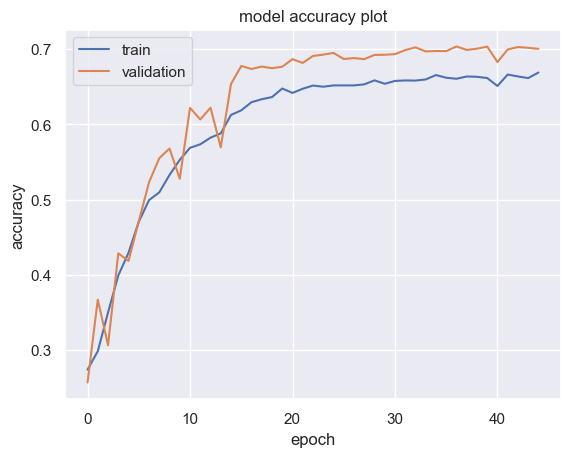

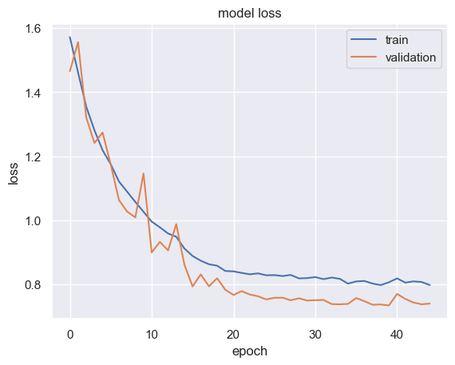

```python
plt.plot(history_cnn4.history['accuracy'])
plt.plot(history_cnn4.history['val_accuracy'])

plt.title('model accuracy plot')
plt.ylabel('accuracy')
plt.xlabel('epoch')
plt.legend(['train', 'validation'])

plt.show()

plt.plot(history_cnn4.history['loss'])
plt.plot(history_cnn4.history['val_loss'])

plt.title('model loss')
plt.ylabel('loss')
plt.xlabel('epoch')
plt.legend(['train', 'validation'])

plt.show()
```

```python
test_images, test_labels = next(test_set)
accuracy = cnn4.evaluate(test_images, test_labels, verbose = 2)
```

```
4/4 - 0s - 19ms/step - accuracy: 0.6797 - loss: 0.7645
```

```python
#saving model name and accuracy
scoreboard_name.append('cnn4')
scoreboard_acc.append(accuracy)
```

```python
scoreboard.append(['cnn4', accuracy[1]])
```

**Observations and Insights:**

- Our first more complex grayscale model has a train and validation accuracy of 66% and 70% by the 40th epoch, and a test accuracy of 68%.
- This is below our simpler architecture (third grayscale CNN model).
- However, we do no have overfitting here, if anything, the model is underfitting training data.
- The difference with our third CNN is that we chose a kernel size of 2x2 for our convolutional layers, let's change that in the next iteration.

## **Fifth CNN Model (grayscale)**

### **Model Building and Compiling**

**Changes**

- Lets set the kernel size in our convulutional layers to 3x3

```python
backend.clear_session()

np.random.seed(25)
random.seed(25)
tf.random.set_seed(25)
```

```python
def cnn_model_complex1():

    model = Sequential()
    model.add(Input(shape = (IMG_SIZE, IMG_SIZE, 1)))

    # conv1 block
    model.add(Conv2D(filters = 64, kernel_size = (3,3), activation = 'relu', padding='same'))
    model.add(BatchNormalization())
    model.add(LeakyReLU(0.1))
    model.add(MaxPooling2D(pool_size = (2,2)))
    model.add(Dropout(0.2))

    # conv2 block
    model.add(Conv2D(filters = 128, kernel_size = (3,3), activation = 'relu', padding='same'))
    model.add(BatchNormalization())
    model.add(LeakyReLU(0.1))
    model.add(MaxPooling2D(pool_size = (2,2)))
    model.add(Dropout(0.2))

    # conv3 block
    model.add(Conv2D(filters = 512, kernel_size = (3,3), activation = 'relu', padding = 'same'))
    model.add(BatchNormalization())
    model.add(LeakyReLU(0.1))
    model.add(MaxPooling2D(pool_size = (2,2)))
    model.add(Dropout(0.2))

    # conv4 block
    model.add(Conv2D(filters = 512, kernel_size = (3,3), activation = 'relu', padding = 'same'))
    model.add(BatchNormalization())
    model.add(LeakyReLU(0.1))
    model.add(MaxPooling2D(pool_size = (2,2)))
    model.add(Dropout(0.2))

    # conv5 block
    model.add(Conv2D(filters = 512, kernel_size = (3,3), activation = 'relu', padding = 'same'))
    model.add(BatchNormalization())
    model.add(LeakyReLU(0.1))
    model.add(MaxPooling2D(pool_size = (2,2)))
    model.add(Dropout(0.2))

    #flatten
    model.add(Flatten())

    #Dense layers
    model.add(Dense(256))
    model.add(BatchNormalization())
    model.add(Activation('relu'))

    model.add(Dense(512))
    model.add(BatchNormalization())
    model.add(Activation('relu'))
    model.add(Dropout(0.2))

    model.add(Dense(4, activation = 'softmax'))

    opt = SGD(learning_rate = 0.01, momentum = 0.9)

    model.compile(loss = "categorical_crossentropy", optimizer = opt, metrics = ["accuracy"])

    return model
```

```python
cnn5 = cnn_model_complex1()
cnn5.summary()
```

```
Model: "sequential"
```

```
┏━━━━━━━━━━━━━━━━━━━━━━━━━━━━━━━━━┳━━━━━━━━━━━━━━━━━━━━━━━━┳━━━━━━━━━━━━━━━┓
┃ Layer (type)                    ┃ Output Shape           ┃       Param # ┃
┡━━━━━━━━━━━━━━━━━━━━━━━━━━━━━━━━━╇━━━━━━━━━━━━━━━━━━━━━━━━╇━━━━━━━━━━━━━━━┩
│ conv2d (Conv2D)                 │ (None, 48, 48, 64)     │           640 │
├─────────────────────────────────┼────────────────────────┼───────────────┤
│ batch_normalization             │ (None, 48, 48, 64)     │           256 │
│ (BatchNormalization)            │                        │               │
├─────────────────────────────────┼────────────────────────┼───────────────┤
│ leaky_re_lu (LeakyReLU)         │ (None, 48, 48, 64)     │             0 │
├─────────────────────────────────┼────────────────────────┼───────────────┤
│ max_pooling2d (MaxPooling2D)    │ (None, 24, 24, 64)     │             0 │
├─────────────────────────────────┼────────────────────────┼───────────────┤
│ dropout (Dropout)               │ (None, 24, 24, 64)     │             0 │
├─────────────────────────────────┼────────────────────────┼───────────────┤
│ conv2d_1 (Conv2D)               │ (None, 24, 24, 128)    │        73,856 │
├─────────────────────────────────┼────────────────────────┼───────────────┤
│ batch_normalization_1           │ (None, 24, 24, 128)    │           512 │
│ (BatchNormalization)            │                        │               │
├─────────────────────────────────┼────────────────────────┼───────────────┤
│ leaky_re_lu_1 (LeakyReLU)       │ (None, 24, 24, 128)    │             0 │
├─────────────────────────────────┼────────────────────────┼───────────────┤
│ max_pooling2d_1 (MaxPooling2D)  │ (None, 12, 12, 128)    │             0 │
├─────────────────────────────────┼────────────────────────┼───────────────┤
│ dropout_1 (Dropout)             │ (None, 12, 12, 128)    │             0 │
├─────────────────────────────────┼────────────────────────┼───────────────┤
│ conv2d_2 (Conv2D)               │ (None, 12, 12, 512)    │       590,336 │
├─────────────────────────────────┼────────────────────────┼───────────────┤
│ batch_normalization_2           │ (None, 12, 12, 512)    │         2,048 │
│ (BatchNormalization)            │                        │               │
├─────────────────────────────────┼────────────────────────┼───────────────┤
│ leaky_re_lu_2 (LeakyReLU)       │ (None, 12, 12, 512)    │             0 │
├─────────────────────────────────┼────────────────────────┼───────────────┤
│ max_pooling2d_2 (MaxPooling2D)  │ (None, 6, 6, 512)      │             0 │
├─────────────────────────────────┼────────────────────────┼───────────────┤
│ dropout_2 (Dropout)             │ (None, 6, 6, 512)      │             0 │
├─────────────────────────────────┼────────────────────────┼───────────────┤
│ conv2d_3 (Conv2D)               │ (None, 6, 6, 512)      │     2,359,808 │
├─────────────────────────────────┼────────────────────────┼───────────────┤
│ batch_normalization_3           │ (None, 6, 6, 512)      │         2,048 │
│ (BatchNormalization)            │                        │               │
```

[output cut: 23 more lines]

```
│ (BatchNormalization)            │                        │               │
├─────────────────────────────────┼────────────────────────┼───────────────┤
│ activation (Activation)         │ (None, 256)            │             0 │
├─────────────────────────────────┼────────────────────────┼───────────────┤
│ dense_1 (Dense)                 │ (None, 512)            │       131,584 │
├─────────────────────────────────┼────────────────────────┼───────────────┤
│ batch_normalization_6           │ (None, 512)            │         2,048 │
│ (BatchNormalization)            │                        │               │
├─────────────────────────────────┼────────────────────────┼───────────────┤
│ activation_1 (Activation)       │ (None, 512)            │             0 │
├─────────────────────────────────┼────────────────────────┼───────────────┤
│ dropout_5 (Dropout)             │ (None, 512)            │             0 │
├─────────────────────────────────┼────────────────────────┼───────────────┤
│ dense_2 (Dense)                 │ (None, 4)              │         2,052 │
└─────────────────────────────────┴────────────────────────┴───────────────┘
```

```
 Total params: 5,659,396 (21.59 MB)
```

```
 Trainable params: 5,654,404 (21.57 MB)
```

```
 Non-trainable params: 4,992 (19.50 KB)
```

### **Training the Model**

```python
early_stop = EarlyStopping(monitor='val_loss', mode = 'min', patience = 5, verbose = 1, restore_best_weights = True)
checkpoint = ModelCheckpoint('best_model_cnn5.keras', monitor='val_loss', mode = 'min', verbose = 1, save_best_only = True)
reduce_lr = ReduceLROnPlateau(monitor = 'val_loss', factor = 0.2, patience = 3, verbose = 1, min_delta = 0.0001)

history_cnn5 = cnn5.fit(train_set, validation_data = val_set, epochs = 200, verbose = 1, callbacks = [early_stop, checkpoint, reduce_lr])
```

```
473/473 ━━━━━━━━━━━━━━━━━━━━ 0s 74ms/step - accuracy: 0.2599 - loss: 1.6443
Epoch 1: val_loss improved from inf to 1.42083, saving model to best_model_cnn5.keras
473/473 ━━━━━━━━━━━━━━━━━━━━ 41s 82ms/step - accuracy: 0.2599 - loss: 1.6442 - val_accuracy: 0.3450 - val_loss: 1.4208 - learning_rate: 0.0100
473/473 ━━━━━━━━━━━━━━━━━━━━ 0s 74ms/step - accuracy: 0.2790 - loss: 1.4887
Epoch 2: val_loss did not improve from 1.42083
473/473 ━━━━━━━━━━━━━━━━━━━━ 38s 81ms/step - accuracy: 0.2790 - loss: 1.4886 - val_accuracy: 0.2285 - val_loss: 1.5039 - learning_rate: 0.0100
473/473 ━━━━━━━━━━━━━━━━━━━━ 0s 74ms/step - accuracy: 0.3106 - loss: 1.4294
Epoch 3: val_loss did not improve from 1.42083
473/473 ━━━━━━━━━━━━━━━━━━━━ 38s 81ms/step - accuracy: 0.3106 - loss: 1.4294 - val_accuracy: 0.2851 - val_loss: 1.5617 - learning_rate: 0.0100
473/473 ━━━━━━━━━━━━━━━━━━━━ 0s 75ms/step - accuracy: 0.3549 - loss: 1.3498
Epoch 4: val_loss improved from 1.42083 to 1.36340, saving model to best_model_cnn5.keras
473/473 ━━━━━━━━━━━━━━━━━━━━ 39s 83ms/step - accuracy: 0.3550 - loss: 1.3498 - val_accuracy: 0.3868 - val_loss: 1.3634 - learning_rate: 0.0100
473/473 ━━━━━━━━━━━━━━━━━━━━ 0s 75ms/step - accuracy: 0.4009 - loss: 1.2807
Epoch 5: val_loss improved from 1.36340 to 1.23548, saving model to best_model_cnn5.keras
473/473 ━━━━━━━━━━━━━━━━━━━━ 39s 83ms/step - accuracy: 0.4009 - loss: 1.2806 - val_accuracy: 0.4087 - val_loss: 1.2355 - learning_rate: 0.0100
473/473 ━━━━━━━━━━━━━━━━━━━━ 0s 75ms/step - accuracy: 0.4116 - loss: 1.2442
Epoch 6: val_loss improved from 1.23548 to 1.12497, saving model to best_model_cnn5.keras
473/473 ━━━━━━━━━━━━━━━━━━━━ 39s 83ms/step - accuracy: 0.4116 - loss: 1.2442 - val_accuracy: 0.5025 - val_loss: 1.1250 - learning_rate: 0.0100
473/473 ━━━━━━━━━━━━━━━━━━━━ 0s 78ms/step - accuracy: 0.4643 - loss: 1.1819
Epoch 7: val_loss did not improve from 1.12497
473/473 ━━━━━━━━━━━━━━━━━━━━ 40s 85ms/step - accuracy: 0.4643 - loss: 1.1819 - val_accuracy: 0.5162 - val_loss: 1.1441 - learning_rate: 0.0100
473/473 ━━━━━━━━━━━━━━━━━━━━ 0s 79ms/step - accuracy: 0.4915 - loss: 1.1336
Epoch 8: val_loss improved from 1.12497 to 1.11398, saving model to best_model_cnn5.keras
473/473 ━━━━━━━━━━━━━━━━━━━━ 41s 87ms/step - accuracy: 0.4915 - loss: 1.1336 - val_accuracy: 0.5286 - val_loss: 1.1140 - learning_rate: 0.0100
473/473 ━━━━━━━━━━━━━━━━━━━━ 0s 79ms/step - accuracy: 0.5103 - loss: 1.1060
Epoch 9: val_loss improved from 1.11398 to 1.06187, saving model to best_model_cnn5.keras
473/473 ━━━━━━━━━━━━━━━━━━━━ 41s 87ms/step - accuracy: 0.5103 - loss: 1.1060 - val_accuracy: 0.5415 - val_loss: 1.0619 - learning_rate: 0.0100
473/473 ━━━━━━━━━━━━━━━━━━━━ 0s 80ms/step - accuracy: 0.5223 - loss: 1.0787
Epoch 10: val_loss improved from 1.06187 to 1.04929, saving model to best_model_cnn5.keras
473/473 ━━━━━━━━━━━━━━━━━━━━ 42s 88ms/step - accuracy: 0.5223 - loss: 1.0787 - val_accuracy: 0.5445 - val_loss: 1.0493 - learning_rate: 0.0100
473/473 ━━━━━━━━━━━━━━━━━━━━ 0s 81ms/step - accuracy: 0.5357 - loss: 1.0503
Epoch 11: val_loss improved from 1.04929 to 1.00812, saving model to best_model_cnn5.keras
473/473 ━━━━━━━━━━━━━━━━━━━━ 42s 89ms/step - accuracy: 0.5357 - loss: 1.0503 - val_accuracy: 0.5805 - val_loss: 1.0081 - learning_rate: 0.0100
473/473 ━━━━━━━━━━━━━━━━━━━━ 0s 82ms/step - accuracy: 0.5548 - loss: 1.0122
Epoch 12: val_loss did not improve from 1.00812
473/473 ━━━━━━━━━━━━━━━━━━━━ 42s 89ms/step - accuracy: 0.5548 - loss: 1.0122 - val_accuracy: 0.5600 - val_loss: 1.0217 - learning_rate: 0.0100
473/473 ━━━━━━━━━━━━━━━━━━━━ 0s 80ms/step - accuracy: 0.5678 - loss: 1.0000
Epoch 13: val_loss did not improve from 1.00812
473/473 ━━━━━━━━━━━━━━━━━━━━ 42s 88ms/step - accuracy: 0.5678 - loss: 1.0000 - val_accuracy: 0.5489 - val_loss: 1.0617 - learning_rate: 0.0100
473/473 ━━━━━━━━━━━━━━━━━━━━ 0s 79ms/step - accuracy: 0.5782 - loss: 0.9641
```

[output cut: 96 more lines]

```
Epoch 44: val_loss did not improve from 0.70313
473/473 ━━━━━━━━━━━━━━━━━━━━ 44s 92ms/step - accuracy: 0.7173 - loss: 0.6831 - val_accuracy: 0.7153 - val_loss: 0.7081 - learning_rate: 8.0000e-05
473/473 ━━━━━━━━━━━━━━━━━━━━ 0s 82ms/step - accuracy: 0.7101 - loss: 0.6973
Epoch 45: val_loss did not improve from 0.70313

Epoch 45: ReduceLROnPlateau reducing learning rate to 1.599999814061448e-05.
473/473 ━━━━━━━━━━━━━━━━━━━━ 43s 90ms/step - accuracy: 0.7101 - loss: 0.6973 - val_accuracy: 0.7225 - val_loss: 0.7084 - learning_rate: 8.0000e-05
473/473 ━━━━━━━━━━━━━━━━━━━━ 0s 82ms/step - accuracy: 0.7212 - loss: 0.6879
Epoch 46: val_loss did not improve from 0.70313
473/473 ━━━━━━━━━━━━━━━━━━━━ 42s 89ms/step - accuracy: 0.7211 - loss: 0.6879 - val_accuracy: 0.7167 - val_loss: 0.7196 - learning_rate: 1.6000e-05
473/473 ━━━━━━━━━━━━━━━━━━━━ 0s 82ms/step - accuracy: 0.7198 - loss: 0.6918
Epoch 47: val_loss did not improve from 0.70313
473/473 ━━━━━━━━━━━━━━━━━━━━ 42s 89ms/step - accuracy: 0.7198 - loss: 0.6918 - val_accuracy: 0.7133 - val_loss: 0.7124 - learning_rate: 1.6000e-05
Epoch 47: early stopping
Restoring model weights from the end of the best epoch: 42.
```

### **Evaluating the Model on Test Set**

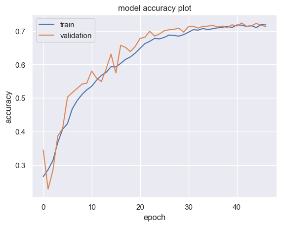

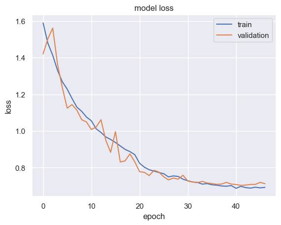

```python
plt.plot(history_cnn5.history['accuracy'])
plt.plot(history_cnn5.history['val_accuracy'])

plt.title('model accuracy plot')
plt.ylabel('accuracy')
plt.xlabel('epoch')
plt.legend(['train', 'validation'])

plt.show()

plt.plot(history_cnn5.history['loss'])
plt.plot(history_cnn5.history['val_loss'])

plt.title('model loss')
plt.ylabel('loss')
plt.xlabel('epoch')
plt.legend(['train', 'validation'])

plt.show()
```

```python
accuracy = cnn5.evaluate(test_images, test_labels, verbose = 2)
```

```
4/4 - 0s - 26ms/step - accuracy: 0.7188 - loss: 0.6160
```

```python
#saving model name and accuracy
scoreboard_name.append('cnn5')
scoreboard_acc.append(accuracy)
```

```python
scoreboard.append(['cnn5', accuracy[1]])
```

**Observations and Insights:**

- The increase in kernel size seems to have benefitted our model.
- This model is also giving a generalized performance.
- We are now sitting at an accuracy of about 71% for both of our training and validation data (an increase of 5% and 1% respectively).
- The accuracy on our test is has also increased by 4% from 68% to 72%.
- Let's stick with this kernel size and lower our learning rate and see if it has a similar effect as what happened with our base CNN models where the higher training rate performed better than the lower one.

## **Sixth CNN Model (grayscale)**

**Changes**

- Let's change our SGD learning rate from 0.01 to 0.001 and compare, earlier we saw that the higher learning rate produced better results more quickly.

### **Model Building and Compiling**

```python
backend.clear_session()

np.random.seed(25)
random.seed(25)
tf.random.set_seed(25)
```

```python
def cnn_model_complex2():

    model = Sequential()
    model.add(Input(shape = (IMG_SIZE, IMG_SIZE, 1)))

    # conv1 block
    model.add(Conv2D(filters = 64, kernel_size = (3,3), activation = 'relu', padding='same'))
    model.add(BatchNormalization())
    model.add(LeakyReLU(0.1))
    model.add(MaxPooling2D(pool_size = (2,2)))
    model.add(Dropout(0.2))

    # conv2 block
    model.add(Conv2D(filters = 128, kernel_size = (3,3), activation = 'relu', padding='same'))
    model.add(BatchNormalization())
    model.add(LeakyReLU(0.1))
    model.add(MaxPooling2D(pool_size = (2,2)))
    model.add(Dropout(0.2))

    # conv3 block
    model.add(Conv2D(filters = 512, kernel_size = (3,3), activation = 'relu', padding = 'same'))
    model.add(BatchNormalization())
    model.add(LeakyReLU(0.1))
    model.add(MaxPooling2D(pool_size = (2,2)))
    model.add(Dropout(0.2))

    # conv4 block
    model.add(Conv2D(filters = 512, kernel_size = (3,3), activation = 'relu', padding = 'same'))
    model.add(BatchNormalization())
    model.add(LeakyReLU(0.1))
    model.add(MaxPooling2D(pool_size = (2,2)))
    model.add(Dropout(0.2))

    # conv5 block
    model.add(Conv2D(filters = 512, kernel_size = (3,3), activation = 'relu', padding = 'same'))
    model.add(BatchNormalization())
    model.add(LeakyReLU(0.1))
    model.add(MaxPooling2D(pool_size = (2,2)))
    model.add(Dropout(0.2))

    #flatten
    model.add(Flatten())

    #Dense layers
    model.add(Dense(256))
    model.add(BatchNormalization())
    model.add(Activation('relu'))

    model.add(Dense(512))
    model.add(BatchNormalization())
    model.add(Activation('relu'))
    model.add(Dropout(0.2))

    model.add(Dense(4, activation = 'softmax'))

    opt = SGD(learning_rate = 0.001, momentum = 0.9)

    model.compile(loss = "categorical_crossentropy", optimizer = opt, metrics = ["accuracy"])

    return model
```

```python
cnn6 = cnn_model_complex2()
cnn6.summary()
```

```
Model: "sequential"
```

```
┏━━━━━━━━━━━━━━━━━━━━━━━━━━━━━━━━━┳━━━━━━━━━━━━━━━━━━━━━━━━┳━━━━━━━━━━━━━━━┓
┃ Layer (type)                    ┃ Output Shape           ┃       Param # ┃
┡━━━━━━━━━━━━━━━━━━━━━━━━━━━━━━━━━╇━━━━━━━━━━━━━━━━━━━━━━━━╇━━━━━━━━━━━━━━━┩
│ conv2d (Conv2D)                 │ (None, 48, 48, 64)     │           640 │
├─────────────────────────────────┼────────────────────────┼───────────────┤
│ batch_normalization             │ (None, 48, 48, 64)     │           256 │
│ (BatchNormalization)            │                        │               │
├─────────────────────────────────┼────────────────────────┼───────────────┤
│ leaky_re_lu (LeakyReLU)         │ (None, 48, 48, 64)     │             0 │
├─────────────────────────────────┼────────────────────────┼───────────────┤
│ max_pooling2d (MaxPooling2D)    │ (None, 24, 24, 64)     │             0 │
├─────────────────────────────────┼────────────────────────┼───────────────┤
│ dropout (Dropout)               │ (None, 24, 24, 64)     │             0 │
├─────────────────────────────────┼────────────────────────┼───────────────┤
│ conv2d_1 (Conv2D)               │ (None, 24, 24, 128)    │        73,856 │
├─────────────────────────────────┼────────────────────────┼───────────────┤
│ batch_normalization_1           │ (None, 24, 24, 128)    │           512 │
│ (BatchNormalization)            │                        │               │
├─────────────────────────────────┼────────────────────────┼───────────────┤
│ leaky_re_lu_1 (LeakyReLU)       │ (None, 24, 24, 128)    │             0 │
├─────────────────────────────────┼────────────────────────┼───────────────┤
│ max_pooling2d_1 (MaxPooling2D)  │ (None, 12, 12, 128)    │             0 │
├─────────────────────────────────┼────────────────────────┼───────────────┤
│ dropout_1 (Dropout)             │ (None, 12, 12, 128)    │             0 │
├─────────────────────────────────┼────────────────────────┼───────────────┤
│ conv2d_2 (Conv2D)               │ (None, 12, 12, 512)    │       590,336 │
├─────────────────────────────────┼────────────────────────┼───────────────┤
│ batch_normalization_2           │ (None, 12, 12, 512)    │         2,048 │
│ (BatchNormalization)            │                        │               │
├─────────────────────────────────┼────────────────────────┼───────────────┤
│ leaky_re_lu_2 (LeakyReLU)       │ (None, 12, 12, 512)    │             0 │
├─────────────────────────────────┼────────────────────────┼───────────────┤
│ max_pooling2d_2 (MaxPooling2D)  │ (None, 6, 6, 512)      │             0 │
├─────────────────────────────────┼────────────────────────┼───────────────┤
│ dropout_2 (Dropout)             │ (None, 6, 6, 512)      │             0 │
├─────────────────────────────────┼────────────────────────┼───────────────┤
│ conv2d_3 (Conv2D)               │ (None, 6, 6, 512)      │     2,359,808 │
├─────────────────────────────────┼────────────────────────┼───────────────┤
│ batch_normalization_3           │ (None, 6, 6, 512)      │         2,048 │
│ (BatchNormalization)            │                        │               │
```

[output cut: 23 more lines]

```
│ (BatchNormalization)            │                        │               │
├─────────────────────────────────┼────────────────────────┼───────────────┤
│ activation (Activation)         │ (None, 256)            │             0 │
├─────────────────────────────────┼────────────────────────┼───────────────┤
│ dense_1 (Dense)                 │ (None, 512)            │       131,584 │
├─────────────────────────────────┼────────────────────────┼───────────────┤
│ batch_normalization_6           │ (None, 512)            │         2,048 │
│ (BatchNormalization)            │                        │               │
├─────────────────────────────────┼────────────────────────┼───────────────┤
│ activation_1 (Activation)       │ (None, 512)            │             0 │
├─────────────────────────────────┼────────────────────────┼───────────────┤
│ dropout_5 (Dropout)             │ (None, 512)            │             0 │
├─────────────────────────────────┼────────────────────────┼───────────────┤
│ dense_2 (Dense)                 │ (None, 4)              │         2,052 │
└─────────────────────────────────┴────────────────────────┴───────────────┘
```

```
 Total params: 5,659,396 (21.59 MB)
```

```
 Trainable params: 5,654,404 (21.57 MB)
```

```
 Non-trainable params: 4,992 (19.50 KB)
```

### **Training the Model**

```python
early_stop = EarlyStopping(monitor='val_loss', mode = 'min', patience = 5, verbose = 1, restore_best_weights = True)
checkpoint = ModelCheckpoint('best_model_cnn6.keras', monitor='val_loss', mode = 'min', verbose = 1, save_best_only = True)
reduce_lr = ReduceLROnPlateau(monitor = 'val_loss', factor = 0.2, patience = 3, verbose = 1, min_delta = 0.0001)

history_cnn6 = cnn6.fit(train_set, validation_data = val_set, epochs = 200, verbose = 1, callbacks = [early_stop, checkpoint, reduce_lr])
```

```
473/473 ━━━━━━━━━━━━━━━━━━━━ 0s 81ms/step - accuracy: 0.2671 - loss: 1.5776
Epoch 1: val_loss improved from inf to 1.38287, saving model to best_model_cnn6.keras
473/473 ━━━━━━━━━━━━━━━━━━━━ 44s 89ms/step - accuracy: 0.2671 - loss: 1.5774 - val_accuracy: 0.2449 - val_loss: 1.3829 - learning_rate: 0.0010
473/473 ━━━━━━━━━━━━━━━━━━━━ 0s 81ms/step - accuracy: 0.2910 - loss: 1.4421
Epoch 2: val_loss improved from 1.38287 to 1.33473, saving model to best_model_cnn6.keras
473/473 ━━━━━━━━━━━━━━━━━━━━ 42s 88ms/step - accuracy: 0.2910 - loss: 1.4421 - val_accuracy: 0.3765 - val_loss: 1.3347 - learning_rate: 0.0010
473/473 ━━━━━━━━━━━━━━━━━━━━ 0s 80ms/step - accuracy: 0.3211 - loss: 1.3786
Epoch 3: val_loss improved from 1.33473 to 1.24965, saving model to best_model_cnn6.keras
473/473 ━━━━━━━━━━━━━━━━━━━━ 42s 88ms/step - accuracy: 0.3212 - loss: 1.3786 - val_accuracy: 0.4123 - val_loss: 1.2496 - learning_rate: 0.0010
473/473 ━━━━━━━━━━━━━━━━━━━━ 0s 80ms/step - accuracy: 0.3659 - loss: 1.3079
Epoch 4: val_loss improved from 1.24965 to 1.23852, saving model to best_model_cnn6.keras
473/473 ━━━━━━━━━━━━━━━━━━━━ 42s 88ms/step - accuracy: 0.3659 - loss: 1.3079 - val_accuracy: 0.4338 - val_loss: 1.2385 - learning_rate: 0.0010
473/473 ━━━━━━━━━━━━━━━━━━━━ 0s 80ms/step - accuracy: 0.3983 - loss: 1.2518
Epoch 5: val_loss did not improve from 1.23852
473/473 ━━━━━━━━━━━━━━━━━━━━ 42s 88ms/step - accuracy: 0.3983 - loss: 1.2518 - val_accuracy: 0.4240 - val_loss: 1.2497 - learning_rate: 0.0010
473/473 ━━━━━━━━━━━━━━━━━━━━ 0s 80ms/step - accuracy: 0.4234 - loss: 1.2213
Epoch 6: val_loss improved from 1.23852 to 1.13941, saving model to best_model_cnn6.keras
473/473 ━━━━━━━━━━━━━━━━━━━━ 42s 88ms/step - accuracy: 0.4235 - loss: 1.2212 - val_accuracy: 0.4991 - val_loss: 1.1394 - learning_rate: 0.0010
473/473 ━━━━━━━━━━━━━━━━━━━━ 0s 81ms/step - accuracy: 0.4602 - loss: 1.1756
Epoch 7: val_loss improved from 1.13941 to 1.06549, saving model to best_model_cnn6.keras
473/473 ━━━━━━━━━━━━━━━━━━━━ 42s 88ms/step - accuracy: 0.4602 - loss: 1.1756 - val_accuracy: 0.5363 - val_loss: 1.0655 - learning_rate: 0.0010
473/473 ━━━━━━━━━━━━━━━━━━━━ 0s 80ms/step - accuracy: 0.4673 - loss: 1.1471
Epoch 8: val_loss improved from 1.06549 to 1.06092, saving model to best_model_cnn6.keras
473/473 ━━━━━━━━━━━━━━━━━━━━ 42s 88ms/step - accuracy: 0.4673 - loss: 1.1471 - val_accuracy: 0.5339 - val_loss: 1.0609 - learning_rate: 0.0010
473/473 ━━━━━━━━━━━━━━━━━━━━ 0s 82ms/step - accuracy: 0.4939 - loss: 1.1100
Epoch 9: val_loss did not improve from 1.06092
473/473 ━━━━━━━━━━━━━━━━━━━━ 42s 89ms/step - accuracy: 0.4939 - loss: 1.1100 - val_accuracy: 0.5254 - val_loss: 1.0972 - learning_rate: 0.0010
473/473 ━━━━━━━━━━━━━━━━━━━━ 0s 82ms/step - accuracy: 0.5187 - loss: 1.0898
Epoch 10: val_loss did not improve from 1.06092
473/473 ━━━━━━━━━━━━━━━━━━━━ 43s 90ms/step - accuracy: 0.5187 - loss: 1.0898 - val_accuracy: 0.4826 - val_loss: 1.1828 - learning_rate: 0.0010
473/473 ━━━━━━━━━━━━━━━━━━━━ 0s 82ms/step - accuracy: 0.5273 - loss: 1.0571
Epoch 11: val_loss improved from 1.06092 to 0.99598, saving model to best_model_cnn6.keras
473/473 ━━━━━━━━━━━━━━━━━━━━ 42s 90ms/step - accuracy: 0.5273 - loss: 1.0571 - val_accuracy: 0.5584 - val_loss: 0.9960 - learning_rate: 0.0010
473/473 ━━━━━━━━━━━━━━━━━━━━ 0s 82ms/step - accuracy: 0.5465 - loss: 1.0361
Epoch 12: val_loss did not improve from 0.99598
473/473 ━━━━━━━━━━━━━━━━━━━━ 43s 90ms/step - accuracy: 0.5465 - loss: 1.0361 - val_accuracy: 0.5437 - val_loss: 1.0534 - learning_rate: 0.0010
473/473 ━━━━━━━━━━━━━━━━━━━━ 0s 81ms/step - accuracy: 0.5632 - loss: 1.0040
Epoch 13: val_loss improved from 0.99598 to 0.97673, saving model to best_model_cnn6.keras
473/473 ━━━━━━━━━━━━━━━━━━━━ 42s 89ms/step - accuracy: 0.5632 - loss: 1.0040 - val_accuracy: 0.5891 - val_loss: 0.9767 - learning_rate: 0.0010
473/473 ━━━━━━━━━━━━━━━━━━━━ 0s 82ms/step - accuracy: 0.5639 - loss: 0.9949
```

[output cut: 76 more lines]

```
Epoch 38: val_loss did not improve from 0.70705
473/473 ━━━━━━━━━━━━━━━━━━━━ 40s 85ms/step - accuracy: 0.6938 - loss: 0.7474 - val_accuracy: 0.7165 - val_loss: 0.7096 - learning_rate: 4.0000e-05
473/473 ━━━━━━━━━━━━━━━━━━━━ 0s 78ms/step - accuracy: 0.6863 - loss: 0.7540
Epoch 39: val_loss did not improve from 0.70705

Epoch 39: ReduceLROnPlateau reducing learning rate to 8.000000525498762e-06.
473/473 ━━━━━━━━━━━━━━━━━━━━ 41s 85ms/step - accuracy: 0.6863 - loss: 0.7540 - val_accuracy: 0.7083 - val_loss: 0.7125 - learning_rate: 4.0000e-05
473/473 ━━━━━━━━━━━━━━━━━━━━ 0s 78ms/step - accuracy: 0.6838 - loss: 0.7614
Epoch 40: val_loss did not improve from 0.70705
473/473 ━━━━━━━━━━━━━━━━━━━━ 41s 86ms/step - accuracy: 0.6838 - loss: 0.7614 - val_accuracy: 0.7161 - val_loss: 0.7140 - learning_rate: 8.0000e-06
473/473 ━━━━━━━━━━━━━━━━━━━━ 0s 79ms/step - accuracy: 0.6792 - loss: 0.7619
Epoch 41: val_loss did not improve from 0.70705
473/473 ━━━━━━━━━━━━━━━━━━━━ 41s 86ms/step - accuracy: 0.6792 - loss: 0.7619 - val_accuracy: 0.7133 - val_loss: 0.7085 - learning_rate: 8.0000e-06
Epoch 41: early stopping
Restoring model weights from the end of the best epoch: 36.
```

### **Evaluating the Model on Test Set**

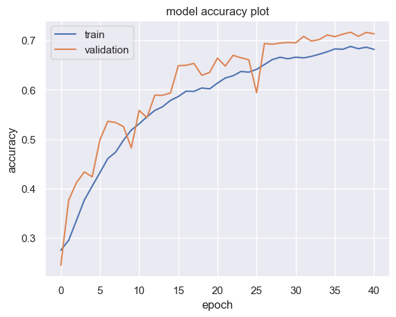

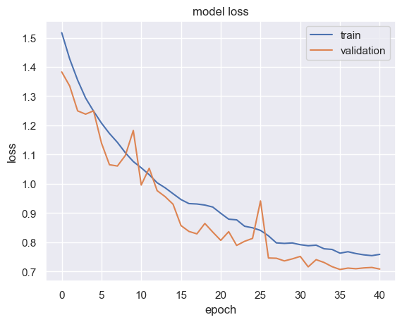

```python
plt.plot(history_cnn6.history['accuracy'])
plt.plot(history_cnn6.history['val_accuracy'])

plt.title('model accuracy plot')
plt.ylabel('accuracy')
plt.xlabel('epoch')
plt.legend(['train', 'validation'])

plt.show()

plt.plot(history_cnn6.history['loss'])
plt.plot(history_cnn6.history['val_loss'])

plt.title('model loss')
plt.ylabel('loss')
plt.xlabel('epoch')
plt.legend(['train', 'validation'])

plt.show()
```

```python
accuracy = cnn6.evaluate(test_images, test_labels, verbose = 2)
```

```
4/4 - 0s - 22ms/step - accuracy: 0.7422 - loss: 0.5990
```

```python
#saving model name and accuracy
scoreboard_name.append('cnn6')
scoreboard_acc.append(accuracy)
```

```python
scoreboard.append(['cnn6', accuracy[1]])
```

**Observations and Insights:**

- It seems like again, the lower initial training rate negatively impacted our models training and validation accuracies.
- However, this model has produced better results on the test set. The accuracy has improved by 2% and the loss has stayed about the same.
- We also note that our validation data has performed better than our training data which could be due to the imbalances that we have.
- We have also lost a bit of the generalized performance that we got with our previous model with the higher learning rate.

## **Seventh CNN Model (grayscale)**

### **Model Building and Compiling**

**Changes**

- Let's change the number of filters in our first and third convolutional block (fewer filters)
- Let's also choose a learning rate between our last two attempts and set it to 0.005
- Removing some dropout layers and increase the ones with have to 0.3 instead of 0.2

```python
backend.clear_session()

np.random.seed(25)
random.seed(25)
tf.random.set_seed(25)
```

```python
def cnn_model_complex3():

    model = Sequential()
    model.add(Input(shape = (IMG_SIZE, IMG_SIZE, 1)))

    # conv1 block
    model.add(Conv2D(filters = 32, kernel_size = (3,3), activation = 'relu', padding='same'))
    model.add(BatchNormalization())
    model.add(Activation('relu'))
    model.add(MaxPooling2D(pool_size = (2,2)))

    # conv2 block
    model.add(Conv2D(filters = 128, kernel_size = (3,3), activation = 'relu', padding='same'))
    model.add(BatchNormalization())
    model.add(Activation('relu'))
    model.add(MaxPooling2D(pool_size = (2,2)))
    model.add(Dropout(0.3))

    # conv3 block
    model.add(Conv2D(filters = 256, kernel_size = (3,3), activation = 'relu', padding = 'same'))
    model.add(BatchNormalization())
    model.add(Activation('relu'))
    model.add(MaxPooling2D(pool_size = (2,2)))

    # conv4 block
    model.add(Conv2D(filters = 512, kernel_size = (3,3), activation = 'relu', padding = 'same'))
    model.add(BatchNormalization())
    model.add(Activation('relu'))
    model.add(MaxPooling2D(pool_size = (2,2)))
    model.add(Dropout(0.3))

    # conv5 block
    model.add(Conv2D(filters = 512, kernel_size = (3,3), activation = 'relu', padding = 'same'))
    model.add(BatchNormalization())
    model.add(Activation('relu'))
    model.add(MaxPooling2D(pool_size = (2,2)))

    #flatten
    model.add(Flatten())

    #Dense layers
    model.add(Dense(256))
    model.add(BatchNormalization())
    model.add(Activation('relu'))
    model.add(Dropout(0.3))

    model.add(Dense(512))
    model.add(BatchNormalization())
    model.add(Activation('relu'))
    model.add(Dropout(0.3))

    model.add(Dense(4, activation = 'softmax'))

    opt = SGD(learning_rate = 0.005, momentum = 0.9)

    model.compile(loss = "categorical_crossentropy", optimizer = opt, metrics = ["accuracy"])

    return model
```

```python
cnn7 = cnn_model_complex3()
cnn7.summary()
```

```
Model: "sequential"
```

```
┏━━━━━━━━━━━━━━━━━━━━━━━━━━━━━━━━━┳━━━━━━━━━━━━━━━━━━━━━━━━┳━━━━━━━━━━━━━━━┓
┃ Layer (type)                    ┃ Output Shape           ┃       Param # ┃
┡━━━━━━━━━━━━━━━━━━━━━━━━━━━━━━━━━╇━━━━━━━━━━━━━━━━━━━━━━━━╇━━━━━━━━━━━━━━━┩
│ conv2d (Conv2D)                 │ (None, 48, 48, 32)     │           320 │
├─────────────────────────────────┼────────────────────────┼───────────────┤
│ batch_normalization             │ (None, 48, 48, 32)     │           128 │
│ (BatchNormalization)            │                        │               │
├─────────────────────────────────┼────────────────────────┼───────────────┤
│ activation (Activation)         │ (None, 48, 48, 32)     │             0 │
├─────────────────────────────────┼────────────────────────┼───────────────┤
│ max_pooling2d (MaxPooling2D)    │ (None, 24, 24, 32)     │             0 │
├─────────────────────────────────┼────────────────────────┼───────────────┤
│ conv2d_1 (Conv2D)               │ (None, 24, 24, 128)    │        36,992 │
├─────────────────────────────────┼────────────────────────┼───────────────┤
│ batch_normalization_1           │ (None, 24, 24, 128)    │           512 │
│ (BatchNormalization)            │                        │               │
├─────────────────────────────────┼────────────────────────┼───────────────┤
│ activation_1 (Activation)       │ (None, 24, 24, 128)    │             0 │
├─────────────────────────────────┼────────────────────────┼───────────────┤
│ max_pooling2d_1 (MaxPooling2D)  │ (None, 12, 12, 128)    │             0 │
├─────────────────────────────────┼────────────────────────┼───────────────┤
│ dropout (Dropout)               │ (None, 12, 12, 128)    │             0 │
├─────────────────────────────────┼────────────────────────┼───────────────┤
│ conv2d_2 (Conv2D)               │ (None, 12, 12, 256)    │       295,168 │
├─────────────────────────────────┼────────────────────────┼───────────────┤
│ batch_normalization_2           │ (None, 12, 12, 256)    │         1,024 │
│ (BatchNormalization)            │                        │               │
├─────────────────────────────────┼────────────────────────┼───────────────┤
│ activation_2 (Activation)       │ (None, 12, 12, 256)    │             0 │
├─────────────────────────────────┼────────────────────────┼───────────────┤
│ max_pooling2d_2 (MaxPooling2D)  │ (None, 6, 6, 256)      │             0 │
├─────────────────────────────────┼────────────────────────┼───────────────┤
│ conv2d_3 (Conv2D)               │ (None, 6, 6, 512)      │     1,180,160 │
├─────────────────────────────────┼────────────────────────┼───────────────┤
│ batch_normalization_3           │ (None, 6, 6, 512)      │         2,048 │
│ (BatchNormalization)            │                        │               │
├─────────────────────────────────┼────────────────────────┼───────────────┤
│ activation_3 (Activation)       │ (None, 6, 6, 512)      │             0 │
├─────────────────────────────────┼────────────────────────┼───────────────┤
│ max_pooling2d_3 (MaxPooling2D)  │ (None, 3, 3, 512)      │             0 │
```

[output cut: 19 more lines]

```
│ activation_5 (Activation)       │ (None, 256)            │             0 │
├─────────────────────────────────┼────────────────────────┼───────────────┤
│ dropout_2 (Dropout)             │ (None, 256)            │             0 │
├─────────────────────────────────┼────────────────────────┼───────────────┤
│ dense_1 (Dense)                 │ (None, 512)            │       131,584 │
├─────────────────────────────────┼────────────────────────┼───────────────┤
│ batch_normalization_6           │ (None, 512)            │         2,048 │
│ (BatchNormalization)            │                        │               │
├─────────────────────────────────┼────────────────────────┼───────────────┤
│ activation_6 (Activation)       │ (None, 512)            │             0 │
├─────────────────────────────────┼────────────────────────┼───────────────┤
│ dropout_3 (Dropout)             │ (None, 512)            │             0 │
├─────────────────────────────────┼────────────────────────┼───────────────┤
│ dense_2 (Dense)                 │ (None, 4)              │         2,052 │
└─────────────────────────────────┴────────────────────────┴───────────────┘
```

```
 Total params: 4,146,244 (15.82 MB)
```

```
 Trainable params: 4,141,828 (15.80 MB)
```

```
 Non-trainable params: 4,416 (17.25 KB)
```

### **Training the Model**

```python
early_stop = EarlyStopping(monitor='val_loss', mode = 'min', patience = 5, verbose = 1, restore_best_weights = True)
checkpoint = ModelCheckpoint('best_model_cnn7.keras', monitor='val_loss', mode = 'min', verbose = 1, save_best_only = True)
reduce_lr = ReduceLROnPlateau(monitor = 'val_loss', factor = 0.2, patience = 3, verbose = 1, min_delta = 0.0001)

history_cnn7 = cnn7.fit(train_set, validation_data = val_set, epochs = 200, verbose = 1, callbacks = [early_stop, checkpoint, reduce_lr])
```

```
472/473 ━━━━━━━━━━━━━━━━━━━━ 0s 45ms/step - accuracy: 0.2716 - loss: 1.6146
Epoch 1: val_loss improved from inf to 1.41150, saving model to best_model_cnn7.keras
473/473 ━━━━━━━━━━━━━━━━━━━━ 27s 52ms/step - accuracy: 0.2716 - loss: 1.6143 - val_accuracy: 0.2479 - val_loss: 1.4115 - learning_rate: 0.0050
472/473 ━━━━━━━━━━━━━━━━━━━━ 0s 44ms/step - accuracy: 0.3005 - loss: 1.4439
Epoch 2: val_loss improved from 1.41150 to 1.25203, saving model to best_model_cnn7.keras
473/473 ━━━━━━━━━━━━━━━━━━━━ 24s 51ms/step - accuracy: 0.3006 - loss: 1.4438 - val_accuracy: 0.4205 - val_loss: 1.2520 - learning_rate: 0.0050
472/473 ━━━━━━━━━━━━━━━━━━━━ 0s 45ms/step - accuracy: 0.3537 - loss: 1.3622
Epoch 3: val_loss improved from 1.25203 to 1.23504, saving model to best_model_cnn7.keras
473/473 ━━━━━━━━━━━━━━━━━━━━ 24s 51ms/step - accuracy: 0.3537 - loss: 1.3622 - val_accuracy: 0.4175 - val_loss: 1.2350 - learning_rate: 0.0050
473/473 ━━━━━━━━━━━━━━━━━━━━ 0s 44ms/step - accuracy: 0.3964 - loss: 1.3022
Epoch 4: val_loss did not improve from 1.23504
473/473 ━━━━━━━━━━━━━━━━━━━━ 24s 51ms/step - accuracy: 0.3964 - loss: 1.3022 - val_accuracy: 0.4081 - val_loss: 1.2665 - learning_rate: 0.0050
472/473 ━━━━━━━━━━━━━━━━━━━━ 0s 45ms/step - accuracy: 0.4452 - loss: 1.2195
Epoch 5: val_loss improved from 1.23504 to 1.18786, saving model to best_model_cnn7.keras
473/473 ━━━━━━━━━━━━━━━━━━━━ 24s 51ms/step - accuracy: 0.4452 - loss: 1.2195 - val_accuracy: 0.4587 - val_loss: 1.1879 - learning_rate: 0.0050
472/473 ━━━━━━━━━━━━━━━━━━━━ 0s 45ms/step - accuracy: 0.4702 - loss: 1.1738
Epoch 6: val_loss improved from 1.18786 to 1.05435, saving model to best_model_cnn7.keras
473/473 ━━━━━━━━━━━━━━━━━━━━ 24s 51ms/step - accuracy: 0.4703 - loss: 1.1737 - val_accuracy: 0.5158 - val_loss: 1.0544 - learning_rate: 0.0050
472/473 ━━━━━━━━━━━━━━━━━━━━ 0s 45ms/step - accuracy: 0.5246 - loss: 1.0838
Epoch 7: val_loss improved from 1.05435 to 0.95435, saving model to best_model_cnn7.keras
473/473 ━━━━━━━━━━━━━━━━━━━━ 24s 51ms/step - accuracy: 0.5246 - loss: 1.0838 - val_accuracy: 0.5941 - val_loss: 0.9543 - learning_rate: 0.0050
473/473 ━━━━━━━━━━━━━━━━━━━━ 0s 44ms/step - accuracy: 0.5460 - loss: 1.0294
Epoch 8: val_loss did not improve from 0.95435
473/473 ━━━━━━━━━━━━━━━━━━━━ 24s 51ms/step - accuracy: 0.5460 - loss: 1.0294 - val_accuracy: 0.5503 - val_loss: 1.0451 - learning_rate: 0.0050
473/473 ━━━━━━━━━━━━━━━━━━━━ 0s 44ms/step - accuracy: 0.5719 - loss: 0.9963
Epoch 9: val_loss did not improve from 0.95435
473/473 ━━━━━━━━━━━━━━━━━━━━ 24s 51ms/step - accuracy: 0.5719 - loss: 0.9963 - val_accuracy: 0.5785 - val_loss: 0.9575 - learning_rate: 0.0050
473/473 ━━━━━━━━━━━━━━━━━━━━ 0s 44ms/step - accuracy: 0.5873 - loss: 0.9650
Epoch 10: val_loss improved from 0.95435 to 0.86474, saving model to best_model_cnn7.keras
473/473 ━━━━━━━━━━━━━━━━━━━━ 24s 51ms/step - accuracy: 0.5873 - loss: 0.9650 - val_accuracy: 0.6323 - val_loss: 0.8647 - learning_rate: 0.0050
472/473 ━━━━━━━━━━━━━━━━━━━━ 0s 45ms/step - accuracy: 0.6093 - loss: 0.9186
Epoch 11: val_loss improved from 0.86474 to 0.82644, saving model to best_model_cnn7.keras
473/473 ━━━━━━━━━━━━━━━━━━━━ 24s 51ms/step - accuracy: 0.6093 - loss: 0.9186 - val_accuracy: 0.6574 - val_loss: 0.8264 - learning_rate: 0.0050
473/473 ━━━━━━━━━━━━━━━━━━━━ 0s 45ms/step - accuracy: 0.6159 - loss: 0.9014
Epoch 12: val_loss did not improve from 0.82644
473/473 ━━━━━━━━━━━━━━━━━━━━ 24s 51ms/step - accuracy: 0.6158 - loss: 0.9014 - val_accuracy: 0.6096 - val_loss: 0.9203 - learning_rate: 0.0050
472/473 ━━━━━━━━━━━━━━━━━━━━ 0s 45ms/step - accuracy: 0.6179 - loss: 0.8900
Epoch 13: val_loss did not improve from 0.82644
473/473 ━━━━━━━━━━━━━━━━━━━━ 24s 51ms/step - accuracy: 0.6179 - loss: 0.8900 - val_accuracy: 0.6072 - val_loss: 0.9465 - learning_rate: 0.0050
472/473 ━━━━━━━━━━━━━━━━━━━━ 0s 45ms/step - accuracy: 0.6410 - loss: 0.8578
```

[output cut: 64 more lines]

```
Epoch 34: val_loss did not improve from 0.68069
473/473 ━━━━━━━━━━━━━━━━━━━━ 24s 51ms/step - accuracy: 0.7230 - loss: 0.6834 - val_accuracy: 0.7189 - val_loss: 0.6895 - learning_rate: 2.0000e-04
472/473 ━━━━━━━━━━━━━━━━━━━━ 0s 45ms/step - accuracy: 0.7298 - loss: 0.6525
Epoch 35: val_loss did not improve from 0.68069

Epoch 35: ReduceLROnPlateau reducing learning rate to 3.9999996079131965e-05.
473/473 ━━━━━━━━━━━━━━━━━━━━ 24s 51ms/step - accuracy: 0.7298 - loss: 0.6525 - val_accuracy: 0.7185 - val_loss: 0.6870 - learning_rate: 2.0000e-04
473/473 ━━━━━━━━━━━━━━━━━━━━ 0s 45ms/step - accuracy: 0.7224 - loss: 0.6843
Epoch 36: val_loss did not improve from 0.68069
473/473 ━━━━━━━━━━━━━━━━━━━━ 24s 51ms/step - accuracy: 0.7224 - loss: 0.6843 - val_accuracy: 0.7253 - val_loss: 0.6853 - learning_rate: 4.0000e-05
472/473 ━━━━━━━━━━━━━━━━━━━━ 0s 45ms/step - accuracy: 0.7203 - loss: 0.6803
Epoch 37: val_loss did not improve from 0.68069
473/473 ━━━━━━━━━━━━━━━━━━━━ 24s 51ms/step - accuracy: 0.7203 - loss: 0.6803 - val_accuracy: 0.7213 - val_loss: 0.6862 - learning_rate: 4.0000e-05
Epoch 37: early stopping
Restoring model weights from the end of the best epoch: 32.
```

### **Evaluating the Model on Test Set**

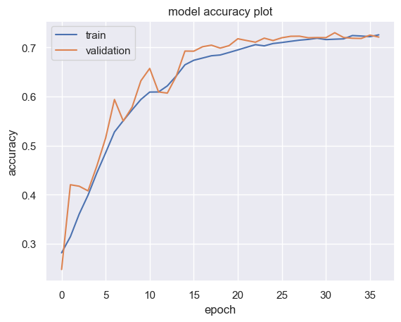

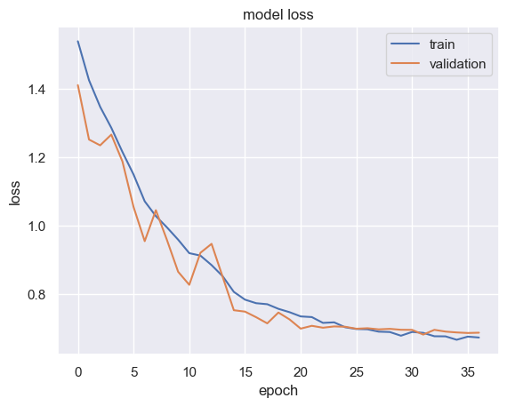

```python
plt.plot(history_cnn7.history['accuracy'])
plt.plot(history_cnn7.history['val_accuracy'])

plt.title('model accuracy plot')
plt.ylabel('accuracy')
plt.xlabel('epoch')
plt.legend(['train', 'validation'])

plt.show()

plt.plot(history_cnn7.history['loss'])
plt.plot(history_cnn7.history['val_loss'])

plt.title('model loss')
plt.ylabel('loss')
plt.xlabel('epoch')
plt.legend(['train', 'validation'])

plt.show()
```

```python
accuracy = cnn7.evaluate(test_images, test_labels, verbose = 2)
```

```
4/4 - 0s - 17ms/step - accuracy: 0.8281 - loss: 0.5516
```

```python
#saving model name and accuracy
scoreboard_name.append('cnn7')
scoreboard_acc.append(accuracy)
```

```python
scoreboard.append(['cnn7', accuracy[1]])
```

**Observations and Insights:**

- Our current best model performance on the test set sitting at about 83% accuracy and 0.55 loss, an increase of 9% accuracy and decrease of 0.05 loss compared to our last model.
- This model is giving a generalized performance, this looks very promising.
- The accuracy and loss of our training and validation data sits around 72% and 0.68 respectively, an increase of 4% accuracy compared to our last model (loss is similar).
- It looks like we are getting to a sweet spot with respect to learning rate, dropout layers, and the number of filters.

## **Eighth CNN Model (grayscale) Improving Third CNN Model**

### **Model Building and Compiling**

- Let's go back to our third cnn from earlier and see if we can optimize its performance by adding a few dropout layers

```python
backend.clear_session()

np.random.seed(25)
random.seed(25)
tf.random.set_seed(25)
```

```python
def cnn_model_1v2():

    model = Sequential()
    model.add(Input(shape = (IMG_SIZE, IMG_SIZE, 1))) #input layer

    model.add(Conv2D(filters = 256, kernel_size = (3,3), activation = 'relu', padding='same')) # conv1
    model.add(BatchNormalization())
    model.add(LeakyReLU(0.1))
    model.add(MaxPooling2D(pool_size=(2,2)))
    model.add(Dropout(0.2))

    model.add(Conv2D(filters = 128, kernel_size = (3,3), activation = 'relu', padding='same')) #conv 2
    model.add(BatchNormalization())
    model.add(LeakyReLU(0.1))
    model.add(MaxPooling2D(pool_size=(2,2)))
    model.add(Dropout(0.2))


    model.add(Conv2D(filters = 64, kernel_size = (3,3), activation = 'relu', padding='same')) #conv 3
    model.add(BatchNormalization())
    model.add(LeakyReLU(0.1))
    model.add(MaxPooling2D(pool_size=(2,2)))

    model.add(Conv2D(filters = 32, kernel_size = (3,3), activation = 'relu', padding='same')) #conv 4
    model.add(BatchNormalization())
    model.add(LeakyReLU(0.1))
    model.add(MaxPooling2D(pool_size=(2,2)))

    model.add(Flatten())

    model.add(Dense(512, activation = 'relu'))
    model.add(Dropout(0.2))

    model.add(Dense(128, activation = 'relu'))
    model.add(Dropout(0.2))

    model.add(Dense(4, activation = 'softmax')) #output layer

    opt = SGD(learning_rate = 0.01, momentum = 0.9)

    model.compile(loss = "categorical_crossentropy", optimizer = opt, metrics = ["accuracy"])

    return model
```

```python
cnn8 = cnn_model_1v2()
cnn8.summary()
```

```
Model: "sequential"
```

```
┏━━━━━━━━━━━━━━━━━━━━━━━━━━━━━━━━━┳━━━━━━━━━━━━━━━━━━━━━━━━┳━━━━━━━━━━━━━━━┓
┃ Layer (type)                    ┃ Output Shape           ┃       Param # ┃
┡━━━━━━━━━━━━━━━━━━━━━━━━━━━━━━━━━╇━━━━━━━━━━━━━━━━━━━━━━━━╇━━━━━━━━━━━━━━━┩
│ conv2d (Conv2D)                 │ (None, 48, 48, 256)    │         2,560 │
├─────────────────────────────────┼────────────────────────┼───────────────┤
│ batch_normalization             │ (None, 48, 48, 256)    │         1,024 │
│ (BatchNormalization)            │                        │               │
├─────────────────────────────────┼────────────────────────┼───────────────┤
│ leaky_re_lu (LeakyReLU)         │ (None, 48, 48, 256)    │             0 │
├─────────────────────────────────┼────────────────────────┼───────────────┤
│ max_pooling2d (MaxPooling2D)    │ (None, 24, 24, 256)    │             0 │
├─────────────────────────────────┼────────────────────────┼───────────────┤
│ dropout (Dropout)               │ (None, 24, 24, 256)    │             0 │
├─────────────────────────────────┼────────────────────────┼───────────────┤
│ conv2d_1 (Conv2D)               │ (None, 24, 24, 128)    │       295,040 │
├─────────────────────────────────┼────────────────────────┼───────────────┤
│ batch_normalization_1           │ (None, 24, 24, 128)    │           512 │
│ (BatchNormalization)            │                        │               │
├─────────────────────────────────┼────────────────────────┼───────────────┤
│ leaky_re_lu_1 (LeakyReLU)       │ (None, 24, 24, 128)    │             0 │
├─────────────────────────────────┼────────────────────────┼───────────────┤
│ max_pooling2d_1 (MaxPooling2D)  │ (None, 12, 12, 128)    │             0 │
├─────────────────────────────────┼────────────────────────┼───────────────┤
│ dropout_1 (Dropout)             │ (None, 12, 12, 128)    │             0 │
├─────────────────────────────────┼────────────────────────┼───────────────┤
│ conv2d_2 (Conv2D)               │ (None, 12, 12, 64)     │        73,792 │
├─────────────────────────────────┼────────────────────────┼───────────────┤
│ batch_normalization_2           │ (None, 12, 12, 64)     │           256 │
│ (BatchNormalization)            │                        │               │
├─────────────────────────────────┼────────────────────────┼───────────────┤
│ leaky_re_lu_2 (LeakyReLU)       │ (None, 12, 12, 64)     │             0 │
├─────────────────────────────────┼────────────────────────┼───────────────┤
│ max_pooling2d_2 (MaxPooling2D)  │ (None, 6, 6, 64)       │             0 │
├─────────────────────────────────┼────────────────────────┼───────────────┤
│ conv2d_3 (Conv2D)               │ (None, 6, 6, 32)       │        18,464 │
├─────────────────────────────────┼────────────────────────┼───────────────┤
│ batch_normalization_3           │ (None, 6, 6, 32)       │           128 │
│ (BatchNormalization)            │                        │               │
├─────────────────────────────────┼────────────────────────┼───────────────┤
│ leaky_re_lu_3 (LeakyReLU)       │ (None, 6, 6, 32)       │             0 │
├─────────────────────────────────┼────────────────────────┼───────────────┤
│ max_pooling2d_3 (MaxPooling2D)  │ (None, 3, 3, 32)       │             0 │
├─────────────────────────────────┼────────────────────────┼───────────────┤
│ flatten (Flatten)               │ (None, 288)            │             0 │
├─────────────────────────────────┼────────────────────────┼───────────────┤
│ dense (Dense)                   │ (None, 512)            │       147,968 │
├─────────────────────────────────┼────────────────────────┼───────────────┤
│ dropout_2 (Dropout)             │ (None, 512)            │             0 │
├─────────────────────────────────┼────────────────────────┼───────────────┤
│ dense_1 (Dense)                 │ (None, 128)            │        65,664 │
├─────────────────────────────────┼────────────────────────┼───────────────┤
│ dropout_3 (Dropout)             │ (None, 128)            │             0 │
├─────────────────────────────────┼────────────────────────┼───────────────┤
│ dense_2 (Dense)                 │ (None, 4)              │           516 │
└─────────────────────────────────┴────────────────────────┴───────────────┘
```

```
 Total params: 605,924 (2.31 MB)
```

```
 Trainable params: 604,964 (2.31 MB)
```

```
 Non-trainable params: 960 (3.75 KB)
```

### **Training the Model**

```python
early_stop = EarlyStopping(monitor='val_loss', mode = 'min', patience = 5, verbose = 1, restore_best_weights = True)
checkpoint = ModelCheckpoint('best_model_cnn1v2.keras', monitor='val_loss', mode = 'min', verbose = 1, save_best_only = True)
reduce_lr = ReduceLROnPlateau(monitor = 'val_loss', factor = 0.2, patience = 3, verbose = 1, min_delta = 0.0001)

history_cnn8 = cnn8.fit(train_set, validation_data = val_set, epochs = 200, verbose = 1, callbacks = [early_stop, checkpoint, reduce_lr])
```

```
473/473 ━━━━━━━━━━━━━━━━━━━━ 0s 128ms/step - accuracy: 0.2726 - loss: 1.4473
Epoch 1: val_loss improved from inf to 1.36604, saving model to best_model_cnn1v2.keras
473/473 ━━━━━━━━━━━━━━━━━━━━ 66s 136ms/step - accuracy: 0.2726 - loss: 1.4471 - val_accuracy: 0.2739 - val_loss: 1.3660 - learning_rate: 0.0100
473/473 ━━━━━━━━━━━━━━━━━━━━ 0s 127ms/step - accuracy: 0.3026 - loss: 1.3658
Epoch 2: val_loss improved from 1.36604 to 1.34142, saving model to best_model_cnn1v2.keras
473/473 ━━━━━━━━━━━━━━━━━━━━ 64s 136ms/step - accuracy: 0.3026 - loss: 1.3658 - val_accuracy: 0.3201 - val_loss: 1.3414 - learning_rate: 0.0100
473/473 ━━━━━━━━━━━━━━━━━━━━ 0s 126ms/step - accuracy: 0.3692 - loss: 1.2926
Epoch 3: val_loss improved from 1.34142 to 1.23556, saving model to best_model_cnn1v2.keras
473/473 ━━━━━━━━━━━━━━━━━━━━ 64s 134ms/step - accuracy: 0.3692 - loss: 1.2926 - val_accuracy: 0.4231 - val_loss: 1.2356 - learning_rate: 0.0100
473/473 ━━━━━━━━━━━━━━━━━━━━ 0s 126ms/step - accuracy: 0.4294 - loss: 1.2111
Epoch 4: val_loss improved from 1.23556 to 1.18782, saving model to best_model_cnn1v2.keras
473/473 ━━━━━━━━━━━━━━━━━━━━ 64s 135ms/step - accuracy: 0.4294 - loss: 1.2110 - val_accuracy: 0.4547 - val_loss: 1.1878 - learning_rate: 0.0100
473/473 ━━━━━━━━━━━━━━━━━━━━ 0s 128ms/step - accuracy: 0.4842 - loss: 1.1366
Epoch 5: val_loss improved from 1.18782 to 1.12241, saving model to best_model_cnn1v2.keras
473/473 ━━━━━━━━━━━━━━━━━━━━ 64s 136ms/step - accuracy: 0.4842 - loss: 1.1365 - val_accuracy: 0.4913 - val_loss: 1.1224 - learning_rate: 0.0100
473/473 ━━━━━━━━━━━━━━━━━━━━ 0s 128ms/step - accuracy: 0.5090 - loss: 1.0914
Epoch 6: val_loss improved from 1.12241 to 1.03748, saving model to best_model_cnn1v2.keras
473/473 ━━━━━━━━━━━━━━━━━━━━ 65s 136ms/step - accuracy: 0.5090 - loss: 1.0914 - val_accuracy: 0.5425 - val_loss: 1.0375 - learning_rate: 0.0100
473/473 ━━━━━━━━━━━━━━━━━━━━ 0s 127ms/step - accuracy: 0.5414 - loss: 1.0301
Epoch 7: val_loss did not improve from 1.03748
473/473 ━━━━━━━━━━━━━━━━━━━━ 64s 135ms/step - accuracy: 0.5414 - loss: 1.0301 - val_accuracy: 0.5312 - val_loss: 1.0575 - learning_rate: 0.0100
473/473 ━━━━━━━━━━━━━━━━━━━━ 0s 128ms/step - accuracy: 0.5607 - loss: 0.9929
Epoch 8: val_loss improved from 1.03748 to 0.95906, saving model to best_model_cnn1v2.keras
473/473 ━━━━━━━━━━━━━━━━━━━━ 64s 136ms/step - accuracy: 0.5607 - loss: 0.9929 - val_accuracy: 0.5815 - val_loss: 0.9591 - learning_rate: 0.0100
473/473 ━━━━━━━━━━━━━━━━━━━━ 0s 124ms/step - accuracy: 0.5856 - loss: 0.9577
Epoch 9: val_loss improved from 0.95906 to 0.92583, saving model to best_model_cnn1v2.keras
473/473 ━━━━━━━━━━━━━━━━━━━━ 63s 132ms/step - accuracy: 0.5856 - loss: 0.9577 - val_accuracy: 0.6032 - val_loss: 0.9258 - learning_rate: 0.0100
473/473 ━━━━━━━━━━━━━━━━━━━━ 0s 125ms/step - accuracy: 0.5926 - loss: 0.9317
Epoch 10: val_loss did not improve from 0.92583
473/473 ━━━━━━━━━━━━━━━━━━━━ 63s 133ms/step - accuracy: 0.5926 - loss: 0.9316 - val_accuracy: 0.5752 - val_loss: 1.0072 - learning_rate: 0.0100
473/473 ━━━━━━━━━━━━━━━━━━━━ 0s 125ms/step - accuracy: 0.6060 - loss: 0.9036
Epoch 11: val_loss did not improve from 0.92583
473/473 ━━━━━━━━━━━━━━━━━━━━ 63s 132ms/step - accuracy: 0.6059 - loss: 0.9037 - val_accuracy: 0.6026 - val_loss: 0.9392 - learning_rate: 0.0100
473/473 ━━━━━━━━━━━━━━━━━━━━ 0s 125ms/step - accuracy: 0.6244 - loss: 0.8869
Epoch 12: val_loss improved from 0.92583 to 0.86938, saving model to best_model_cnn1v2.keras
473/473 ━━━━━━━━━━━━━━━━━━━━ 63s 133ms/step - accuracy: 0.6244 - loss: 0.8869 - val_accuracy: 0.6383 - val_loss: 0.8694 - learning_rate: 0.0100
473/473 ━━━━━━━━━━━━━━━━━━━━ 0s 125ms/step - accuracy: 0.6288 - loss: 0.8706
Epoch 13: val_loss improved from 0.86938 to 0.85606, saving model to best_model_cnn1v2.keras
473/473 ━━━━━━━━━━━━━━━━━━━━ 63s 133ms/step - accuracy: 0.6288 - loss: 0.8706 - val_accuracy: 0.6359 - val_loss: 0.8561 - learning_rate: 0.0100
473/473 ━━━━━━━━━━━━━━━━━━━━ 0s 126ms/step - accuracy: 0.6334 - loss: 0.8448
```

[output cut: 75 more lines]

```
Epoch 37: val_loss did not improve from 0.68871
473/473 ━━━━━━━━━━━━━━━━━━━━ 64s 136ms/step - accuracy: 0.7320 - loss: 0.6401 - val_accuracy: 0.7223 - val_loss: 0.6918 - learning_rate: 8.0000e-05
473/473 ━━━━━━━━━━━━━━━━━━━━ 0s 128ms/step - accuracy: 0.7412 - loss: 0.6230
Epoch 38: val_loss did not improve from 0.68871

Epoch 38: ReduceLROnPlateau reducing learning rate to 1.599999814061448e-05.
473/473 ━━━━━━━━━━━━━━━━━━━━ 64s 136ms/step - accuracy: 0.7412 - loss: 0.6230 - val_accuracy: 0.7225 - val_loss: 0.6937 - learning_rate: 8.0000e-05
473/473 ━━━━━━━━━━━━━━━━━━━━ 0s 130ms/step - accuracy: 0.7386 - loss: 0.6334
Epoch 39: val_loss did not improve from 0.68871
473/473 ━━━━━━━━━━━━━━━━━━━━ 66s 139ms/step - accuracy: 0.7386 - loss: 0.6334 - val_accuracy: 0.7221 - val_loss: 0.6916 - learning_rate: 1.6000e-05
473/473 ━━━━━━━━━━━━━━━━━━━━ 0s 131ms/step - accuracy: 0.7390 - loss: 0.6414
Epoch 40: val_loss did not improve from 0.68871
473/473 ━━━━━━━━━━━━━━━━━━━━ 66s 140ms/step - accuracy: 0.7390 - loss: 0.6414 - val_accuracy: 0.7209 - val_loss: 0.6988 - learning_rate: 1.6000e-05
Epoch 40: early stopping
Restoring model weights from the end of the best epoch: 35.
```

### **Evaluating the Model on Test Set**

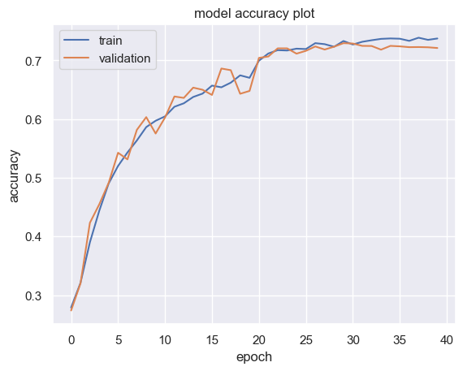

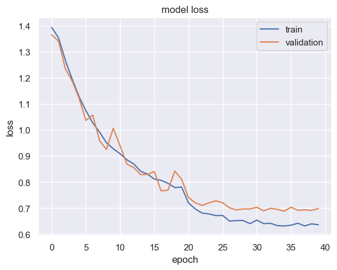

```python
plt.plot(history_cnn8.history['accuracy'])
plt.plot(history_cnn8.history['val_accuracy'])

plt.title('model accuracy plot')
plt.ylabel('accuracy')
plt.xlabel('epoch')
plt.legend(['train', 'validation'])

plt.show()

plt.plot(history_cnn8.history['loss'])
plt.plot(history_cnn8.history['val_loss'])

plt.title('model loss')
plt.ylabel('loss')
plt.xlabel('epoch')
plt.legend(['train', 'validation'])

plt.show()
```

```python
accuracy = cnn8.evaluate(test_images, test_labels, verbose = 2)
```

```
4/4 - 0s - 25ms/step - accuracy: 0.7812 - loss: 0.6068
```

```python
#saving model name and accuracy
scoreboard_name.append('cnn8')
scoreboard_acc.append(accuracy)
```

```python
scoreboard.append(['cnn8', accuracy[1]])
```

- model is giving a slightly worse generalized performance than our previous one but a better generalized performance with respect to its counterpart (Third CNN).
- We've successfully increased its performance from its previous iteration (Third CNN)
- We got an accuracy of 78% on the test set and an accuracy of 73% and 72% on the training and validation data respectively by the 35th epoch with no improvement afterward.